# Pelagic productivity and abundance of competitors modulate trophic niche segregation among large sympatric predators

PART 2: Stable Isotopes Analysis

Version: 02 septiembre, 2025

Load the **drivers** obtained in the previous scripts

- Environmental variables: *Chlorophyll*, *Mixed Layer Depth* and *Pelagic Productivity*
- *Fishing effort*
- *Relative abundance* estimated from standardized nCPUE (ind/1000hooks)

```r
# load abundance
ind <- read.table("CPUE/grid_cpue.csv", sep = ";", dec = ".", header = T)  %>%
  rename(grid = id)  %>%
  select(grid,swo,pgo,ioo,all_sp)

# grid and environment
grid = st_read("spatial/grid_env_fe.shp") %>%
  rename(chl = "c_2015_",
         opf = "o_2015_",
         FE = "f201520",
         MLD = "m_2015_",
         LAT= "centrdY",
         LON = "centrdX") %>%
  mutate(basin = as.factor(ifelse(id > 310, "med", "atl")),
         area = as.factor(ifelse(LAT<32, "can",
                                 ifelse(LON>-5, "med", "por")))) %>%
  dplyr::select(id, LAT, LON, chl, MLD, opf, FE, area, basin) %>%
  mutate(logFE = log(FE+1))
```

# 1 Bulk values

*Table 1*. Mean values and standard deviation (SD) of length, δ13C and δ15N isotopes for mako (IOO), blue shark (PGO), and swordfish (SWO). n: number of samples.

| Species | Area1 | count | mean | sd | range | mean_C | sd_C | mean_N | sd_N | rangeN | rangeC |
| --- | --- | --- | --- | --- | --- | --- | --- | --- | --- | --- | --- |
| IOO | Canarias | 10 | 112.50 | 22.62 | 67-156 | -17.91 | 0.69 | 11.94 | 0.73 | 11.03-13.58 | -18.78–16.44 |
| IOO | Sur Portugal | 19 | 130.21 | 28.21 | 72-189 | -17.78 | 0.71 | 12.56 | 0.70 | 11.38-13.84 | -18.78–16.72 |
| IOO | WMed | 2 | 123.75 | 51.27 | 88-160 | -16.69 | 0.55 | 13.08 | 1.05 | 12.34-13.82 | -17.08–16.3 |
| PGO | Canarias | 50 | 159.00 | 40.36 | 93-237 | -17.67 | 0.97 | 12.65 | 0.64 | 11.22-15.11 | -18.83–14.92 |
| PGO | Sur Portugal | 92 | 148.43 | 36.89 | 82-234 | -17.72 | 0.99 | 12.87 | 0.64 | 10.57-14.22 | -19.29–14.37 |
| PGO | WMed | 45 | 118.81 | 40.89 | 43-218 | -17.49 | 0.96 | 11.29 | 1.32 | 8.54-13.33 | -18.62–14.29 |
| SWO | Canarias | 66 |  |  | NA-NA | -18.25 | 0.48 | 11.94 | 0.77 | 10.34-13.61 | -19.18–16.7 |
| SWO | Sur Portugal | 27 | 103.41 | 7.42 | 80-114 | -18.52 | 0.55 | 11.72 | 0.68 | 10.11-13.36 | -19.35–17.52 |
| SWO | WMed | 160 |  |  | NA-NA | -18.26 | 0.46 | 11.41 | 1.24 | 7.97-14.38 | -19.82–17.02 |

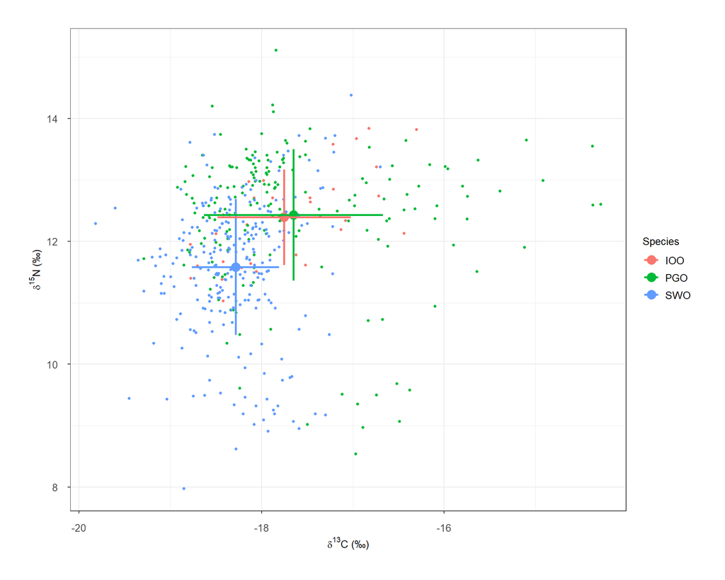

```r
# boxplot for C
A = ggplot(samples, aes(x=Area1, y=dC_corr, fill=Species)) +
  geom_boxplot() +
  ylab(expression(delta^13~C)) +
  xlab("") +
  theme_classic()

# boxplot for N
B = ggplot(samples, aes(x=Area1, y=dN, fill=Species)) +
  geom_boxplot() +
  ylab(expression(delta^15~N)) +
  xlab("") +
  theme_classic()


descriptive <- as.data.frame((group_by(samples, Species) %>%
                                summarise(
                                  count = n(),
                                  mean_dC = mean(dC_corr),
                                  sd_dC = sd(dC_corr),
                                  mean_dN = mean(dN),
                                  sd_dN = sd(dN),
                                )))

ggplot()+
  geom_point(data=descriptive,aes(x=mean_dC,y=mean_dN,colour=Species),size=4)+
  geom_point(data=samples,aes(x=dC_corr,y=dN,colour=Species),size=1)+
  geom_errorbar(data=descriptive,aes(x=mean_dC,y=mean_dN,colour=Species,ymin=mean_dN-sd_dN, ymax=mean_dN+sd_dN), size=1, width=0)+
  geom_errorbarh(data=descriptive,aes(x=mean_dC,y=mean_dN,colour=Species,xmin=mean_dC-sd_dC, xmax=mean_dC+sd_dC), size=1, height=0)+
  theme_bw()+
  labs(x=expression(paste(delta^{13}, "C"," (\u2030)")),y=expression(paste(delta^{15}, "N"," (\u2030)")))+
  theme(plot.title=element_text(size=10),
        axis.text.x=element_text(size=10,margin = margin(t = 10, r = 0, b = 0, l = 0)),
        axis.text.y=element_text(size=10,margin = margin(t = 0, r = 10, b = 0, l = 0)),
        plot.margin = margin(1, 1, 1, 1, "cm"),
        axis.title=element_text(size=10),
        legend.text=element_text(size=10),
        legend.title=element_text(size=10))
```

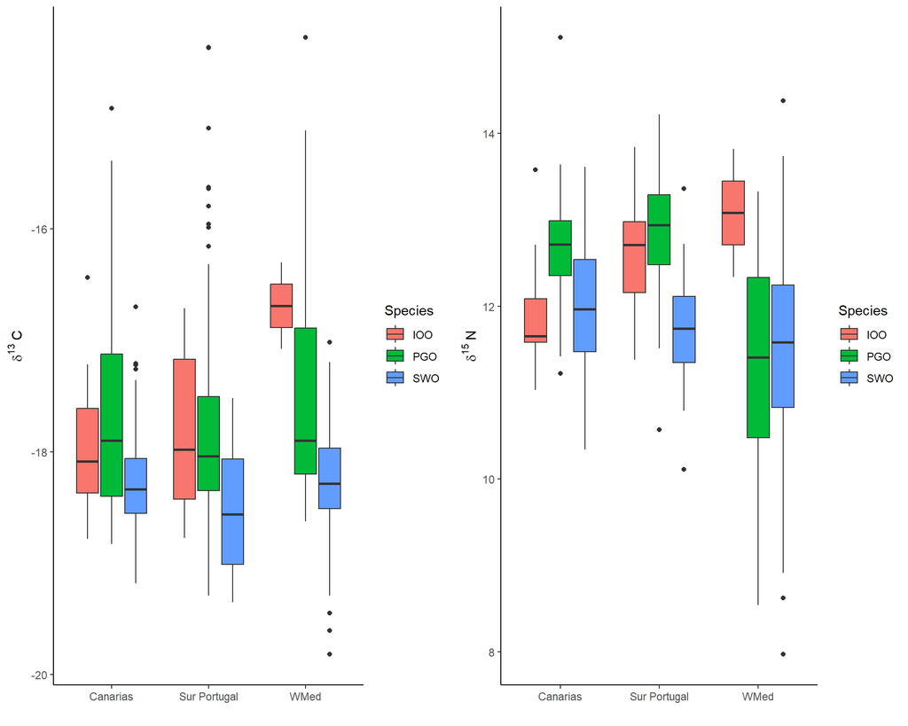

```r
plot_grid(A,B,ncol=2)
```

**Shapiro-Wilk Test** tests for normality—i.e., it checks whether a sample comes from a normal (Gaussian) distribution. Null Hypothesis (H₀): The data are normally distributed.

```r
shapiro.test(subset(samples, Species == "PGO")$dN);shapiro.test(subset(samples, Species == "PGO")$dC_corr)
```

```
#>
#>  Shapiro-Wilk normality test
#>
#> data:  subset(samples, Species == "PGO")$dN
#> W = 0.88949, p-value = 1.563e-10
```

```
#>
#>  Shapiro-Wilk normality test
#>
#> data:  subset(samples, Species == "PGO")$dC_corr
#> W = 0.88012, p-value = 4.619e-11
```

```r
shapiro.test(subset(samples, Species == "SWO")$dN);shapiro.test(subset(samples, Species == "SWO")$dC_corr)
```

```
#>
#>  Shapiro-Wilk normality test
#>
#> data:  subset(samples, Species == "SWO")$dN
#> W = 0.96598, p-value = 1.019e-05
```

```
#>
#>  Shapiro-Wilk normality test
#>
#> data:  subset(samples, Species == "SWO")$dC_corr
#> W = 0.99465, p-value = 0.5177
```

```r
shapiro.test(subset(samples, Species == "IOO")$dN);shapiro.test(subset(samples, Species == "IOO")$dC_corr)
```

```
#>
#>  Shapiro-Wilk normality test
#>
#> data:  subset(samples, Species == "IOO")$dN
#> W = 0.95933, p-value = 0.28
```

```
#>
#>  Shapiro-Wilk normality test
#>
#> data:  subset(samples, Species == "IOO")$dC_corr
#> W = 0.9399, p-value = 0.08201
```

**Is the isotopic composition different between the species and the areas?**

PERMANOVA is a non-parametric test used to compare differences between groups based on a distance matrix. It is used for multivariate data, where the response is composed of multiple variables. It does not assume normality and is based on permutations rather than parametric distributions. Null Hypothesis (H₀): The centroids of the groups in multivariate space are the same (i.e., there is no difference in the community structure or multivariate response between groups).

```r
library(vegan)

CN <- samples[,c(15,17)]
CN[is.na(CN)] = 0

CNdist<- vegdist(CN, method="euclidean")

#PERMANOVA TEST
set.seed(1000)
CN.div<-adonis2(CNdist ~ Area1 + Species + Species/Area1, data=samples,permutations = 9999,method="euclidean") # Area, especie y año como factor
CN.div
```

```
#> Permutation test for adonis under reduced model
#> Permutation: free
#> Number of permutations: 9999
#>
#> adonis2(formula = CNdist ~ Area1 + Species + Species/Area1, data = samples, permutations = 9999, method = "euclidean")
#>           Df SumOfSqs      R2      F Pr(>F)
#> Model      8   186.51 0.26716 21.053  1e-04 ***
#> Residual 462   511.62 0.73284
#> Total    470   698.13 1.00000
#> ---
#> Signif. codes:  0 '***' 0.001 '**' 0.01 '*' 0.05 '.' 0.1 ' ' 1
```

**Paiwise Permanova**

```r
#install_github("pmartinezarbizu/pairwiseAdonis/pairwiseAdonis")
library(pairwiseAdonis)

pairwise.adonis(samples[,c(15,17)],samples$Species, sim.method = "euclidean")
```

```
#>        pairs Df SumsOfSqs   F.Model         R2 p.value p.adjusted sig
#> 1 IOO vs PGO  1  4.630778  3.805988 0.01731522   0.042      0.126
#> 2 IOO vs SWO  1 20.244348 14.803516 0.04987648   0.001      0.003   *
#> 3 PGO vs SWO  1 79.376335 60.908435 0.12208339   0.001      0.003   *
```

```r
pairwise.adonis(samples[,c(15,17)],samples$Area1, sim.method = "euclidean")
```

```
#>                      pairs Df  SumsOfSqs  F.Model         R2 p.value p.adjusted
#> 1     WMed vs Sur Portugal  1 119.762278 86.18608 0.20081285   0.001      0.003
#> 2         WMed vs Canarias  1  53.466161 39.15743 0.10578589   0.001      0.003
#> 3 Sur Portugal vs Canarias  1   9.384354 11.92873 0.04354682   0.001      0.003
#>   sig
#> 1   *
#> 2   *
#> 3   *
```

## 1.1 Spatial distribution of the SI data

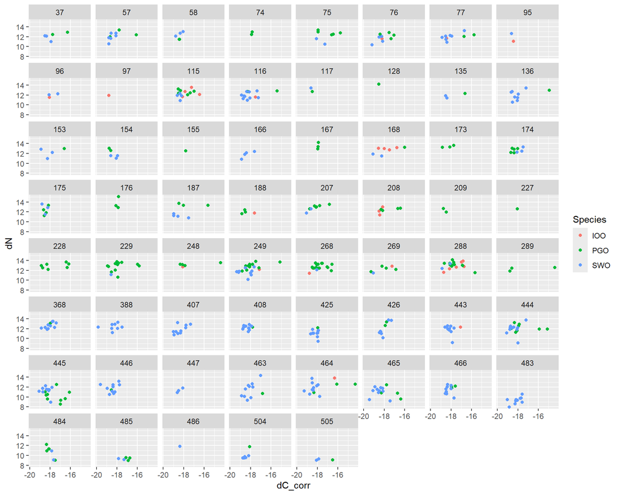

```r
library(sf)

# add gridcell number to the samples
points_sf <- st_as_sf(samples, coords = c("LON", "LAT"), crs = 4326)
samples <- st_join(points_sf, grid[,1]) %>% rename(grid = id)

ggplot(samples) +
  geom_point(aes(dC_corr,dN, colour = Species)) +
  facet_wrap(~grid)
```

# 2 Isotopic niche

The isotopic niche was estimated using Kernel Utilization Density estimators (KUDs) using the rKIN R package v1.0.2 (Albeke, 2023).

**Niche width** and **niche overlap** among species were reported using the 2D KUD of niche size at the 95% confidence level, which provides a good representation of when data are irregularly distributed (Eckrich et al., 2020).

## 2.1 Niche width

### 2.1.1 Niche width per area

```r
#delete cell with less than 3 samples
filtered <- samples %>%
  distinct() %>%
  st_drop_geometry()  %>%
  group_by(grid, Species) %>%
  filter(n() >= 3) %>%
  ungroup()

filtered <-  as.data.frame(filtered)

# CREATE EMPTY DATAFRAME
KUD_area = data.frame(area = NA, species = NA, ConfInt = NA, ShapeArea = NA)
KUD_overlap = data.frame(area = NA, OverlapID = NA, IOO_95= NA, PGO_95= NA, SWO_95= NA)

# CALCULATE AREA AND OVERLAP
for (i in unique(filtered$Area1)){
   #print(i)
  # estimate niche overlap between 2 species using kernel UD and 3 confidence intervals
  test.kin <- estKIN(data=subset(filtered, Area1 == i), x="dC_corr", y="dN", group="Species",levels=c(95), scaler=2, smallSamp = T)
  assign(paste("test.kin", i, sep = "_"), test.kin)

  # Extract the area of each polygon
  kin.area <- getArea(test.kin)
  KUD_area  <-  KUD_area  %>% add_row(
                    species = as.factor(kin.area$Group),
                    ConfInt = kin.area$ConfInt,
                    ShapeArea = kin.area$ShapeArea,
                    area = i)

  # determine polygon overlap for all polygons
  kin.olp <- calcOverlap(test.kin)
  KUD_overlap  <-  KUD_overlap  %>% add_row(
                    OverlapID = as.factor(kin.olp$OverlapID),
                    IOO_95 = kin.olp$IOO_95,
                    PGO_95 = kin.olp$PGO_95,
                    SWO_95 = kin.olp$SWO_95,
                    area = i)

  # plot the kernel estimates
   plot <- plotKIN(test.kin, title=" ", xlab="dC", ylab="dN")

   plot <- plot +
   scale_fill_manual(values = c("IOO_95" = "#b2182b", "PGO_95" = "#ef8a62",  "SWO_95" = "#2166ac"))  +
   scale_color_manual(values = c("IOO" = "#b2182b", "PGO" = "#ef8a62",  "SWO" = "#2166ac")) +
   scale_shape_manual(values = c(16, 16, 16)) +
   coord_sf(xlim = c(-21, -13), ylim = c(7, 16))

  assign(paste("KUD_plot", i, sep = "_"), plot)

  # Save the plot as pdf
  pdf_filename <- paste("SIA/KUD_", i, ".pdf", sep = "")
  #ggsave(filename = pdf_filename, plot = plot, width = 8, height = 6, units = "in", dpi = 300)
}

#write.table(KUD_area[-1,],"SIA/KUD_area.csv", sep = ";", dec = ".", row.names = F)
#write.table(KUD_overlap[-1,],"SIA/KUD_overlap.csv", sep = ";", dec = ".", row.names = F)

# isotopic niche area
kable(KUD_area[-1,], caption = "*Table S2* Isotopic niche estimates based on 95% kernel utilization densities (KUD) for swordfish, mako, and blue sharks captured in the Canary Islands, the South of Portugal, and the western Mediterranean Sea.")
```

*Table S2* Isotopic niche estimates based on 95% kernel utilization densities (KUD) for swordfish, mako, and blue sharks captured in the Canary Islands, the South of Portugal, and the western Mediterranean Sea.

|  | area | species | ConfInt | ShapeArea |
| --- | --- | --- | --- | --- |
| 2 | Sur Portugal | IOO | 95 | 9.231769 |
| 3 | Sur Portugal | PGO | 95 | 10.664286 |
| 4 | Sur Portugal | SWO | 95 | 7.404687 |
| 5 | Canarias | IOO | 95 | 11.994183 |
| 6 | Canarias | PGO | 95 | 9.707244 |
| 7 | Canarias | SWO | 95 | 6.995907 |
| 8 | WMed | PGO | 95 | 24.608413 |
| 9 | WMed | SWO | 95 | 10.302591 |

```r
# isotopic niche area overlap
kable(KUD_overlap[-1,], caption = "*Table S2* The percentage of overlap of the isotopic area of groups is shown as the first column group versus the ones of the first row. ")
```

*Table S2* The percentage of overlap of the isotopic area of groups is shown as the first column group versus the ones of the first row.

|  | area | OverlapID | IOO_95 | PGO_95 | SWO_95 |
| --- | --- | --- | --- | --- | --- |
| 2 | Sur Portugal | IOO_95 | 1.000 | 0.816 | 0.487 |
| 3 | Sur Portugal | PGO_95 | 0.706 | 1.000 | 0.348 |
| 4 | Sur Portugal | SWO_95 | 0.607 | 0.501 | 1.000 |
| 5 | Canarias | IOO_95 | 1.000 | 0.686 | 0.490 |
| 6 | Canarias | PGO_95 | 0.848 | 1.000 | 0.558 |
| 7 | Canarias | SWO_95 | 0.840 | 0.775 | 1.000 |
| 8 | WMed | PGO_95 |  | 1.000 | 0.386 |
| 9 | WMed | SWO_95 |  | 0.921 | 1.000 |

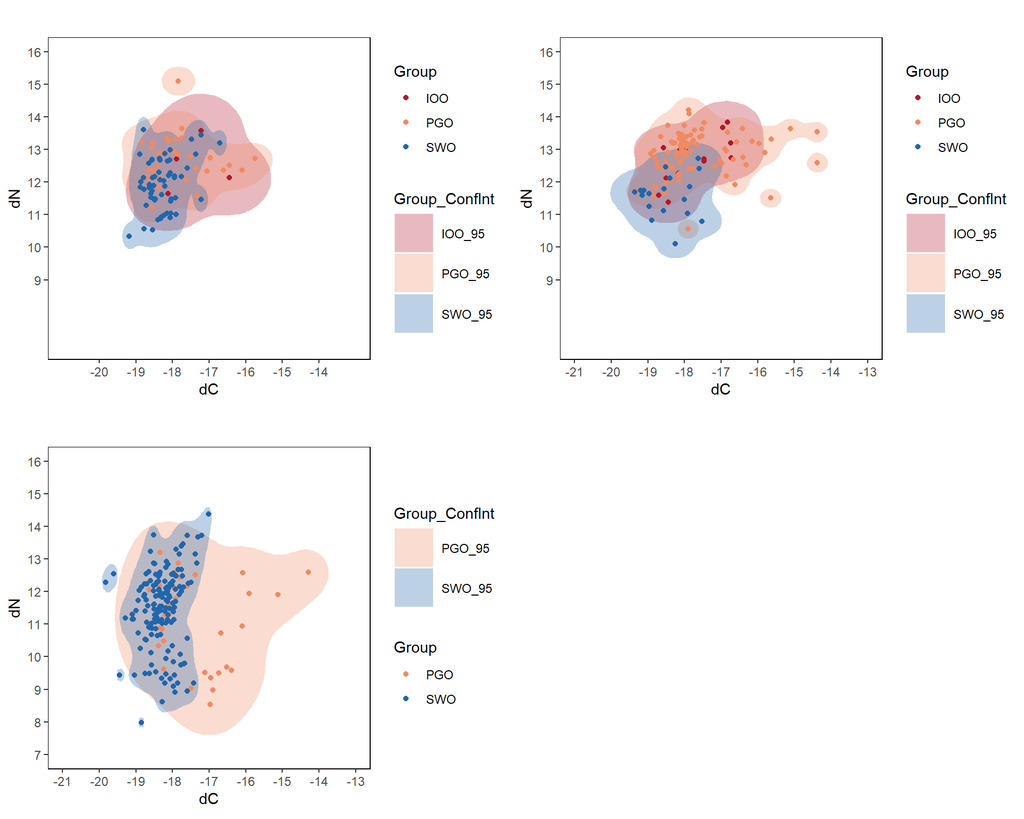

*Figure 1.* (b) Isotopic niche estimates based on 95% kernel utilization densities for swordfish, shortfin mako, and blue shark.

```r
plot_grid(KUD_plot_Canarias,`KUD_plot_Sur Portugal`,KUD_plot_WMed, ncol=2)
```

### 2.1.2 Niche width per grid cell

Calculate Niche width per grid cell

```r
#Create empty dataframe
kin <-  data.frame(Group = NA,
                   ConfInt = NA,
                   ShapeArea = NA,
                   grid = NA)

for (i in unique(filtered$grid)){
  print(i)
  if (i != 289){
  # estimate niche overlap between 2 species using kernel UD and 3 confidence intervals
  test.kin <- estKIN(data=subset(filtered, grid == i), x="dC_corr", y="dN", group="Species",
                  levels=c(95), scaler=2, smallSamp = T)

  # Extract the area of each polygon
  kin.area <- getArea(test.kin)

  kin  <-  kin  %>% add_row(
                    Group = as.factor(kin.area$Group),
                    ConfInt = kin.area$ConfInt,
                    ShapeArea = kin.area$ShapeArea,
                    grid = i)

  plot <- plotKIN(test.kin, title="Test Kernel UD", xlab="dC", ylab="dN")

  plot <- plot +
   scale_fill_manual(values = c("IOO_95" = "#b2182b", "PGO_95" = "#ef8a62",  "SWO_95" = "#2166ac")) +
   scale_color_manual(values = c("IOO" = "#b2182b", "PGO" = "#ef8a62",  "SWO" = "#2166ac")) +
   scale_shape_manual(values = c(16, 16, 16)) +
   coord_sf(xlim = c(-21, -13), ylim = c(7, 16))

  assign(paste("kin_plot", i, sep = "_"), plot)

  # Save the plot as pdf
  pdf_filename <- paste("SIA/KUD/plot_grid_", i, ".pdf", sep = "")
  ggsave(filename = pdf_filename, plot = plot, width = 8, height = 6, units = "in", dpi = 300)

  } else {
     # estimate niche overlap between 2 species using kernel UD and 3 confidence intervals
  test.kin <- estKIN(data=subset(filtered, grid == i), x="dC", y="dN", group="Species",
                  levels=c(95), scaler=2, smallSamp = T)

  # Extract the area of each polygon
  kin.area <- getArea(test.kin)

  kin  <-  kin  %>% add_row(
                    Group = as.factor(kin.area$Group),
                    ConfInt = kin.area$ConfInt,
                    ShapeArea = kin.area$ShapeArea,
                    grid = i)

  plot <- plotKIN(test.kin, title="Test Kernel UD", xlab="dC", ylab="dN")

  plot <- plot +
   scale_fill_manual(values = c("IOO_95" = "#b2182b", "PGO_95" = "#ef8a62",  "SWO_95" = "#2166ac")) +
   scale_color_manual(values = c("IOO" = "#b2182b", "PGO" = "#ef8a62",  "SWO" = "#2166ac")) +
   scale_shape_manual(values = c(16, 16, 16)) +
   coord_sf(xlim = c(-21, -13), ylim = c(7, 16))

  assign(paste("kin_plot", i, sep = "_"), plot)

  # Save the plot as pdf
  pdf_filename <- paste("SIA/KUD/plot_grid_", i, ".pdf", sep = "")
  ggsave(filename = pdf_filename, plot = plot, width = 8, height = 6, units = "in", dpi = 300)
  }}

#write.table(kin[-1,],"SIA/KUD_area_grid.csv", sep = ";", dec = ".", row.names = F)
```

### 2.1.3 Relationship with drivers

```r
kud = read.table("SIA/KUD/KUD_area_grid.csv", sep = ";", dec = ".", header = T)

# add distance to grid
kud_grid  <- merge(kud, grid, by.x= "grid", by.y ="id")

# add abundance
kud_grid  <- merge(kud_grid, ind, by = "grid", all.x = T)  %>%
  mutate(species = as.factor(Group),
         KUD = ShapeArea,
         abund = ifelse(Group == "PGO", pgo,
                      ifelse(Group == "SWO", swo, ioo)))
```

Explore the relationship between KUD and species and areas.

```r
kud_grid  %>%
  group_by(species, area) %>%
  summarise(
    count = n(),
    mean_KUD = round(mean(KUD),3), sd_KUD = round(sd(KUD),3),
    mean_Abundance = mean(abund, na.rm = T), sd_Abundance = sd(abund, na.rm = T))  %>%
  kable(caption = "mean KUD and abundance by species and area")
```

mean KUD and abundance by species and area

| species | area | count | mean_KUD | sd_KUD | mean_Abundance | sd_Abundance |
| --- | --- | --- | --- | --- | --- | --- |
| IOO | can | 2 | 11.992 | 0.000 | 0.3969243 | 0.0000000 |
| IOO | por | 6 | 5.854 | 5.549 | 0.7069415 | 0.6659571 |
| PGO | can | 16 | 4.927 | 3.882 | 3.3813975 | 0.1169553 |
| PGO | med | 13 | 11.433 | 9.154 | 0.4754678 | 0.3787423 |
| PGO | por | 25 | 4.986 | 3.115 | 9.0663392 | 3.3414566 |
| SWO | can | 17 | 4.339 | 2.477 | 17.6023909 | 1.9188525 |
| SWO | med | 22 | 6.044 | 3.031 | 6.9924865 | 1.9101103 |
| SWO | por | 5 | 4.617 | 1.569 | 12.6244650 | 1.1030916 |

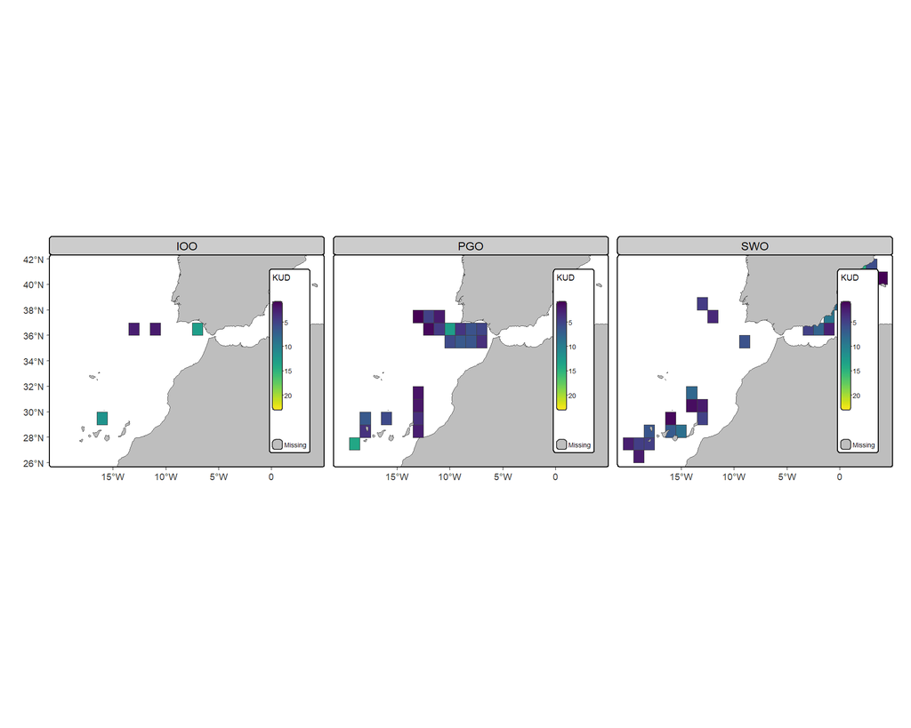

```r
merge(grid[,1], kud_grid[,c(1,2,20)], by.x="id", by.y = "grid")  %>%
  tm_shape(is.master = T) +
    tm_fill(col = "KUD", style = "cont", palette = viridis(100)) +
    tm_layout(legend.position = c("right", "bottom")) +
    tm_facets(by = "Group", ncol = 3, free.coords = FALSE, scale.factor = 1 ) +
    theme_map
```

```r
shapiro.test(kud_grid$KUD)
```

```
#>
#>  Shapiro-Wilk normality test
#>
#> data:  kud_grid$KUD
#> W = 0.84485, p-value = 3.653e-09
```

```r
kruskal.test(KUD ~ species, data = kud_grid)
```

```
#>
#>  Kruskal-Wallis rank sum test
#>
#> data:  KUD by species
#> Kruskal-Wallis chi-squared = 0.36464, df = 2, p-value = 0.8333
```

```r
kruskal.test(KUD ~ area, data = kud_grid)
```

```
#>
#>  Kruskal-Wallis rank sum test
#>
#> data:  KUD by area
#> Kruskal-Wallis chi-squared = 4.6619, df = 2, p-value = 0.0972
```

No observed statistical differences of KUD among species or areas

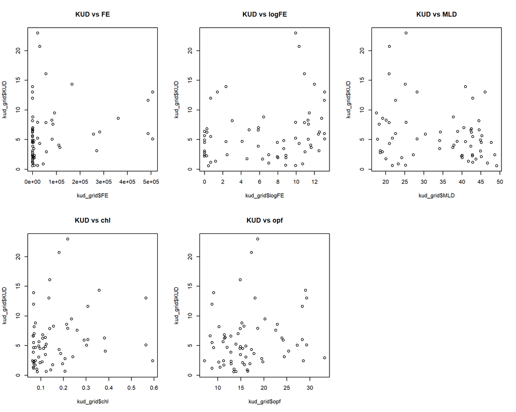

```r
par(mfrow = c(2, 3))
plot(kud_grid$KUD ~ kud_grid$FE, main = "KUD vs FE")
plot(kud_grid$KUD ~ kud_grid$logFE, main = "KUD vs logFE")
plot(kud_grid$KUD ~ kud_grid$MLD, main = "KUD vs MLD")
plot(kud_grid$KUD ~ kud_grid$chl, main = "KUD vs chl")
plot(kud_grid$KUD ~ kud_grid$opf, main = "KUD vs opf")
```

We won’t be modeling the relationship between KUD and the drivers because KUD will be used in the ITP models:

## 2.2 Intraspecific competition (ITP)

The intraspecific competition was estimated using the Intraspecific Trophic Pressure index (ITP; proposed by Andrades et al. (2021))

$$ITP = \frac{\log(Abundance + 1)}{KUD_{ij}}$$
and modified from Pelage et al. (2022), calculated as:

$$ITP_{ij} = \frac{\log(nCPUE_{ij} + 1)}{KUD_{ij}}$$

```r
# calculate ITP
ITP_grid <-  kud_grid  %>%
  mutate(ITP = ifelse(Group == "PGO", log(pgo+1)/KUD,
                  ifelse(Group == "SWO", log(swo+1)/KUD, log(ioo+1)/KUD))) %>%
  dplyr::select(-Group,-ShapeArea, -ConfInt) %>%
  unique()
```

Explore the relationship between ITP and species and areas. Observed differences:

- among species: ITP is higher for swordfish than blue sharks and mako sharks (lowest).
- ITP in the Mediterranean is lower than in the Atlantic.

```r
ITP_grid  %>%
  group_by(species) %>%
  summarise(
    count = n(),
    mean_ITP = mean(ITP, na.rm = T), sd_ITP = sd(ITP, na.rm = T))  %>%
  kable(caption = "mean ITP by species")
```

mean ITP by species

| species | count | mean_ITP | sd_ITP |
| --- | --- | --- | --- |
| IOO | 4 | 0.0802767 | 0.0545675 |
| PGO | 28 | 0.5190851 | 0.6461323 |
| SWO | 32 | 0.7487984 | 0.7593942 |

```r
ITP_grid  %>%
  group_by(area) %>%
  summarise(
    count = n(),
    mean_ITP = mean(ITP, na.rm = T), sd_ITP = sd(ITP, na.rm = T)) %>%
  kable(caption = "mean ITP by area")
```

mean ITP by area

| area | count | mean_ITP | sd_ITP |
| --- | --- | --- | --- |
| can | 21 | 0.7410951 | 0.6412690 |
| med | 24 | 0.4602835 | 0.7422066 |
| por | 19 | 0.6541710 | 0.7188210 |

```r
shapiro.test(ITP_grid$ITP)
```

```
#>
#>  Shapiro-Wilk normality test
#>
#> data:  ITP_grid$ITP
#> W = 0.68188, p-value = 2.111e-10
```

```r
kruskal.test(ITP ~ species, data = ITP_grid)
```

```
#>
#>  Kruskal-Wallis rank sum test
#>
#> data:  ITP by species
#> Kruskal-Wallis chi-squared = 12.231, df = 2, p-value = 0.002208
```

```r
pairwise.wilcox.test(ITP_grid$ITP, ITP_grid$species, p.adjust.method = "BH")
```

```
#>
#>  Pairwise comparisons using Wilcoxon rank sum exact test
#>
#> data:  ITP_grid$ITP and ITP_grid$species
#>
#>     IOO    PGO
#> PGO 0.0342 -
#> SWO 0.0001 0.0465
#>
#> P value adjustment method: BH
```

```r
kruskal.test(ITP ~ area, data = ITP_grid)
```

```
#>
#>  Kruskal-Wallis rank sum test
#>
#> data:  ITP by area
#> Kruskal-Wallis chi-squared = 6.5145, df = 2, p-value = 0.03849
```

```r
pairwise.wilcox.test(ITP_grid$ITP, ITP_grid$area, p.adjust.method = "BH")
```

```
#>
#>  Pairwise comparisons using Wilcoxon rank sum exact test
#>
#> data:  ITP_grid$ITP and ITP_grid$area
#>
#>     can  med
#> med 0.05 -
#> por 0.51 0.11
#>
#> P value adjustment method: BH
```

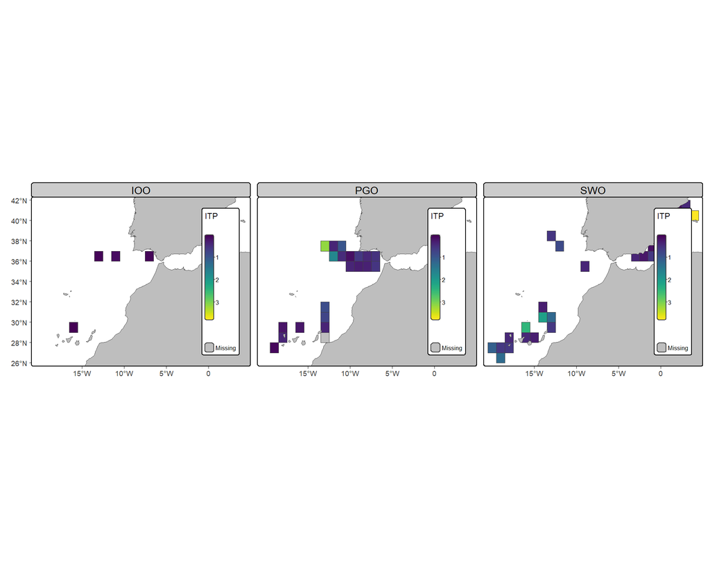

```r
merge(grid[,1], ITP_grid[,-10], by.x="id", by.y = "grid") %>%
  tm_shape(is.master = T) +
    tm_fill(col = "ITP", style = "cont", palette = viridis(100)) +
    tm_layout(legend.position = c("right", "center"),
              outer.margins = c(0.01, 0.01, 0.01, 0.01)) +
    tm_facets(by = "species", ncol = 3, free.coords = FALSE, scale.factor = 2) +
    theme_map
```

#### 2.2.0.1 Relationship with drivers

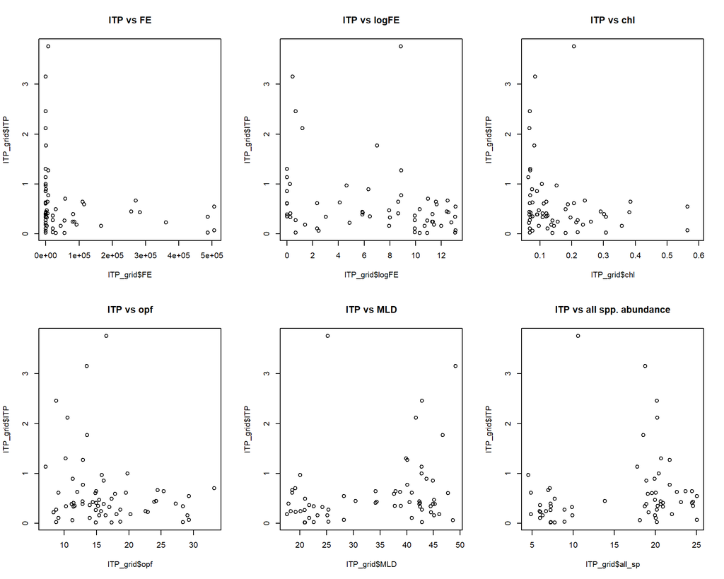

```r
par(mfrow = c(2, 3))
plot(ITP_grid$ITP ~ ITP_grid$FE, main = "ITP vs FE")
plot(ITP_grid$ITP ~ ITP_grid$logFE, main = "ITP vs logFE")
plot(ITP_grid$ITP ~ ITP_grid$chl, main = "ITP vs chl")
plot(ITP_grid$ITP ~ ITP_grid$opf, main = "ITP vs opf")
plot(ITP_grid$ITP ~ ITP_grid$MLD, main = "ITP vs MLD")
plot(ITP_grid$ITP~ITP_grid$all_sp, main = "ITP vs all spp. abundance")
```

> GAM model

```r
ITP <- gam(ITP ~ te(LON,LAT) + s(opf, k =3)  + species,
             data = ITP_grid,  family = Gamma)
summary(ITP)
```

```
#>
#> Family: Gamma
#> Link function: inverse
#>
#> Formula:
#> ITP ~ te(LON, LAT) + s(opf, k = 3) + species
#>
#> Parametric coefficients:
#>             Estimate Std. Error t value Pr(>|t|)
#> (Intercept)   13.613      4.462   3.051  0.00366 **
#> speciesPGO   -11.173      4.463  -2.503  0.01564 *
#> speciesSWO   -11.846      4.464  -2.654  0.01068 *
#> ---
#> Signif. codes:  0 '***' 0.001 '**' 0.01 '*' 0.05 '.' 0.1 ' ' 1
#>
#> Approximate significance of smooth terms:
#>               edf Ref.df     F p-value
#> te(LON,LAT) 8.422   9.87 3.276 0.00267 **
#> s(opf)      2.000   2.00 2.737 0.07451 .
#> ---
#> Signif. codes:  0 '***' 0.001 '**' 0.01 '*' 0.05 '.' 0.1 ' ' 1
#>
#> R-sq.(adj) =  0.425   Deviance explained = 52.7%
#> GCV = 0.8236  Scale est. = 0.51238   n = 63
```

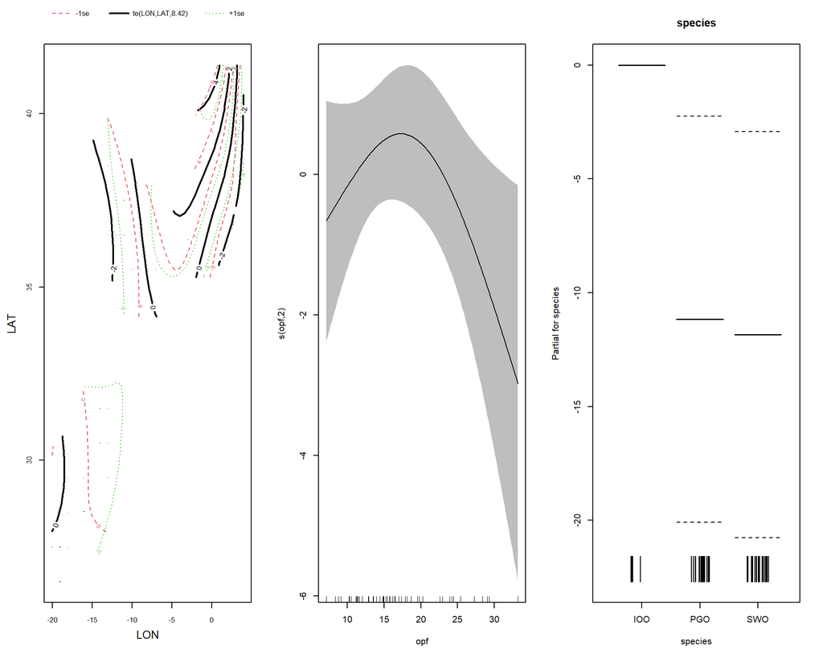

*Figure 4* GAM partial effects of the explanatory variables for (b) the potential intraspecific competition estimated with the Intraspecific Trophic Pressure (ITP) index. Shadowed areas represent 95% confidence intervals around the main effects.

```r
#pdf(file = "GAM/ITP_GAM_dCcorr.pdf", width = 5, height = 5)
par(mfrow = c(1, 3))
plot(ITP, all.terms =T, shade = TRUE, shade.col = "grey", rug = TRUE, seWithMean = TRUE)
```

```r
#dev.off()
```

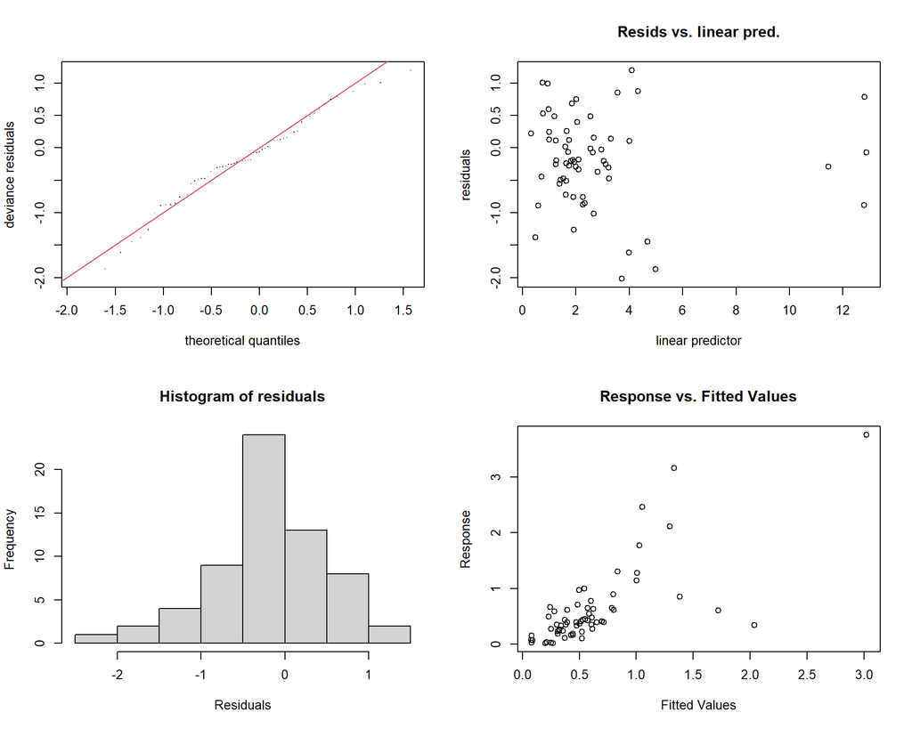

*Figure S4*. Diagnostic plots for the GAMs for the Intraspecific Trophic Pressure (ITP) index.

```
#>
#> Method: GCV   Optimizer: outer newton
#> full convergence after 8 iterations.
#> Gradient range [-2.008962e-07,4.123648e-07]
#> (score 0.8236012 & scale 0.5123839).
#> Hessian positive definite, eigenvalue range [4.124277e-07,0.01073941].
#> Model rank =  29 / 29
#>
#> Basis dimension (k) checking results. Low p-value (k-index<1) may
#> indicate that k is too low, especially if edf is close to k'.
#>
#>                k'   edf k-index p-value
#> te(LON,LAT) 24.00  8.42    1.09    0.95
#> s(opf)       2.00  2.00    1.01    0.78
```

```r
#png("GAM/ITP_dCcorr_gamcheck.png", res = 100, width = 600, height = 600)
par(mfrow = c(2, 2))
gam.check(ITP)
```

```r
#dev.off()
```

## 2.3 Distance to competitor centroids (CCD)

The mean distance to centroid (CD) provides information on niche width but also on individual distribution within the δ13C - δ15N space (Layman et al 2007). Here, CCD is defined as the mean of Euclidean distances between centroid of receiver and those of their competitors and will be used as a proxy for **interspecific competition** (Teichert et al 2024). The CCD thus measures the dietary niche proximity of receiver with their potential competitors in the δ13C - δ15N space. We are going to determine the distance between the niche centroids by using the crossdist() in spatstat.geom() (https://www.geeksforgeeks.org/distance-between-two-sets-of-points-in-r/)

### 2.3.1 Calculate Niche CENTROID and euclidean distances

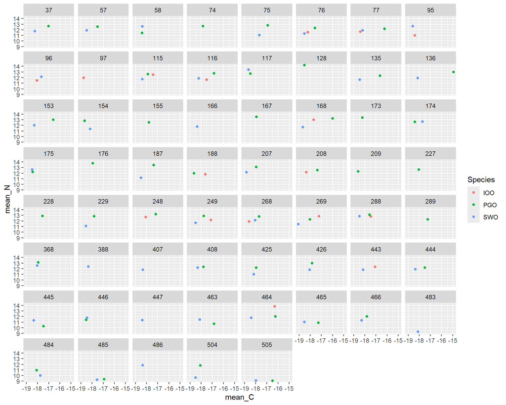

isotopic centroid for each species in each gridcell

```r
# calculate mean N and C for each cell
samples %>%
  group_by(grid, Species) %>%
  summarise(mean_N = mean(dN),
            mean_C = mean(dC_corr))  %>%
  ggplot() +
  geom_point(aes(mean_C,mean_N, colour = Species)) +
  facet_wrap(~grid)
```

```r
centroid <- samples %>%
  st_drop_geometry() %>%
      group_by(Species, grid) %>%
      summarise(meanN = mean(dN), meanC = mean(dC_corr))  %>%
      pivot_wider(names_from = Species, values_from = c(meanN, meanC)) %>%
      mutate(meanN_SWO = replace_na(meanN_SWO, 0), meanN_PGO = replace_na(meanN_PGO, 0), meanN_IOO = replace_na(meanN_IOO, 0))


# calculate euclidean distances
library(spatstat.geom)
dist <- centroid  %>%
  group_by(grid)  %>%
  summarise(
    dist_SP = ifelse(meanN_SWO != 0 & meanN_PGO != 0, crossdist(meanN_PGO, meanC_PGO, meanN_SWO, meanC_SWO), NA),
    dist_SI = ifelse(meanN_SWO != 0 & meanN_IOO != 0, crossdist(meanN_IOO, meanC_IOO, meanN_SWO, meanC_SWO), NA),
    dist_PI = ifelse(meanN_IOO != 0 & meanN_PGO != 0, crossdist(meanN_PGO,meanC_PGO, meanN_IOO, meanC_IOO), NA))

#write.table(dist, "SIA/dist_centroid.csv", sep = ";", dec = ".")
```

### 2.3.2 Relationship with drivers

Explore the relationship between CCD and species and areas.

Merge distances with drivers

```r
# load dist
#dist <- read.table("SIA/dist_centroid.csv", sep = ";", dec = ".", header = T

# add abundance
dist_ind  <- merge(dist, ind, by = "grid")

dist_ind <- dist_ind %>%
  pivot_longer(cols = c("swo","pgo","ioo"), names_to = "species", values_to = "abund") %>%
  mutate(species = as.factor(species)) %>%
  pivot_longer(cols = starts_with("dist_"), names_to = "pair", values_to = "dist_all") %>%
  mutate(dist_all = ifelse(species == "swo" & pair != "dist_PI", dist_all,
                           ifelse(species == "pgo" & pair != "dist_SI", dist_all,
                                 ifelse(species == "ioo" & pair != "dist_SP", dist_all, NA)))) %>%
  drop_na(dist_all)

CCD <- dist_ind %>%
  group_by(grid, all_sp, abund, species) %>%
  summarise(CCD = mean(dist_all))

### add environmental var
dist_grid  <- merge( grid, CCD, by.x= "id", by.y ="grid")
```

```r
ggplot(dist_grid, aes(abund,CCD,colour = species)) + geom_point() + geom_smooth(method="lm")
```

[output not shown]

No observed difference of CCD among species or areas:

```r
# CCD by species
dist_grid %>%
  group_by(area, species, ) %>%
  summarise(
    count = n(),
    mean_CCD = mean(CCD), SD_CCD= sd(CCD)) %>%
  kable(caption = "*Table SX*. Mean and SD CCD by species and area")
```

*Table SX*. Mean and SD CCD by species and area

| area | species | count | mean_CCD | SD_CCD | geometry |
| --- | --- | --- | --- | --- | --- |
| can | ioo | 6 | 1.039438 | 0.3569982 | POLYGON ((-17.524 27.9955, … |
| can | pgo | 15 | 1.465522 | 0.7495257 | MULTIPOLYGON (((-13.524 30…. |
| can | swo | 17 | 1.362861 | 0.6999382 | MULTIPOLYGON (((-13.524 30…. |
| med | ioo | 2 | 1.780109 | 0.8252281 | MULTIPOLYGON (((1.476 40.99… |
| med | pgo | 15 | 1.129457 | 0.5232630 | MULTIPOLYGON (((1.476 37.99… |
| med | swo | 16 | 1.168802 | 0.5831181 | MULTIPOLYGON (((1.476 37.99… |
| por | ioo | 8 | 1.159085 | 0.3549677 | MULTIPOLYGON (((-12.524 36…. |
| por | pgo | 11 | 1.383776 | 0.6124747 | MULTIPOLYGON (((-10.524 36…. |
| por | swo | 8 | 1.622055 | 0.6519768 | MULTIPOLYGON (((-13.524 36…. |

```r
shapiro.test(dist_grid$CCD)
```

```
#>
#>  Shapiro-Wilk normality test
#>
#> data:  dist_grid$CCD
#> W = 0.92676, p-value = 3.902e-05
```

```r
anova = aov(CCD ~ species*area, data =  dist_grid)
summary(anova)
```

```
#>              Df Sum Sq Mean Sq F value Pr(>F)
#> species       2   0.26  0.1292   0.343  0.711
#> area          2   0.98  0.4921   1.305  0.276
#> species:area  4   1.88  0.4692   1.244  0.298
#> Residuals    89  33.56  0.3771
```

```r
#TukeyHSD(anova)
```

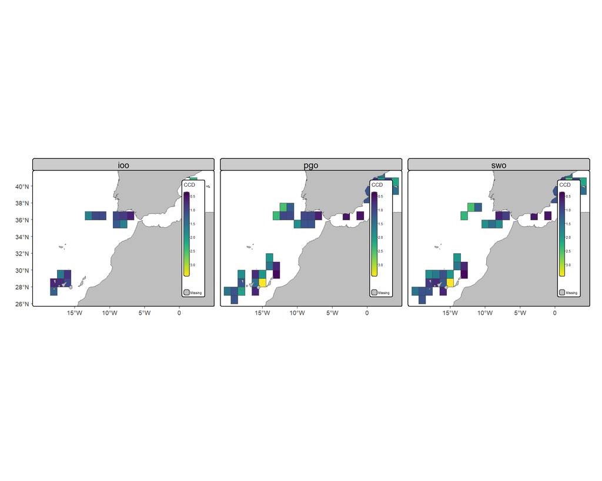

```r
dist_grid %>%
  tm_shape(is.master = T) +
    tm_fill(col = "CCD", style = "cont", palette = viridis(100)) +
    tm_layout(legend.position = c("right", "bottom"))+
    tm_facets(by = "species", ncol = 3, free.coords = FALSE, scale.factor = 2 ) +
    theme_map
```

Explore if CCD is correlated to any of the explanatory variables

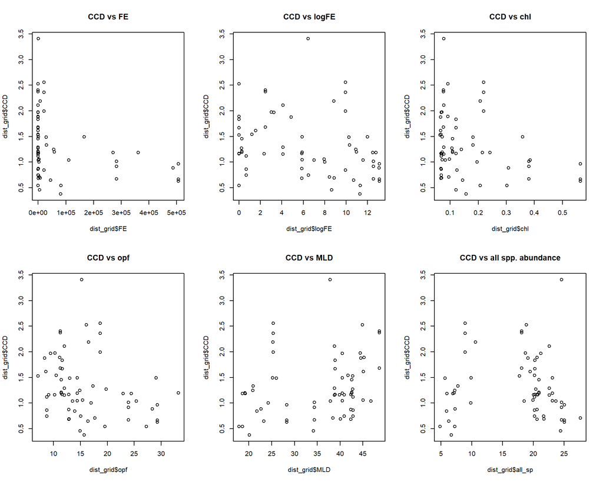

```r
par(mfrow = c(2, 3))
plot(dist_grid$CCD ~ dist_grid$FE, main = "CCD vs FE")
plot(dist_grid$CCD ~ dist_grid$logFE, main = "CCD vs logFE")
plot(dist_grid$CCD ~ dist_grid$chl, main = "CCD vs chl")
plot(dist_grid$CCD ~ dist_grid$opf, main = "CCD vs opf")
plot(dist_grid$CCD ~ dist_grid$MLD, main = "CCD vs MLD")
plot(dist_grid$CCD ~ dist_grid$all_sp, main = "CCD vs all spp. abundance")
```

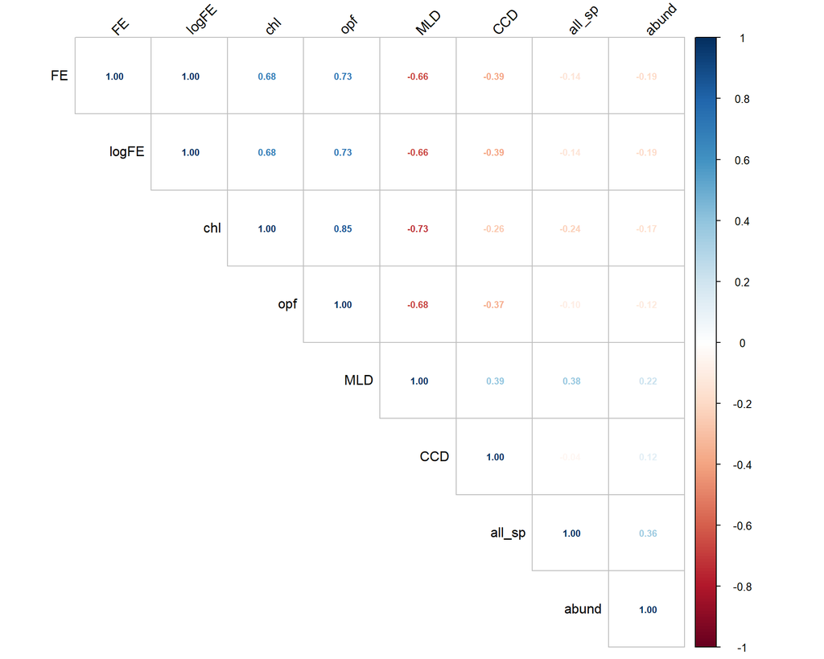

```r
library(corrplot)
dist_grid <- st_drop_geometry(dist_grid)

all_cor <- cor(dist_grid[, c(4:7,10:12,14)], method = "spearman", use = "complete.obs")

corrplot(all_cor, method = "number",type = "upper", order = "hclust",
         tl.col = "black", tl.srt = 45, number.cex = 0.7)
```

> GAM model

```r
CCD_gam<- gam(CCD ~ te(LAT,LON) + s(all_sp),
             data = dist_grid,  family = Gamma)
summary(CCD_gam)
```

```
#>
#> Family: Gamma
#> Link function: inverse
#>
#> Formula:
#> CCD ~ te(LAT, LON) + s(all_sp)
#>
#> Parametric coefficients:
#>             Estimate Std. Error t value Pr(>|t|)
#> (Intercept)  0.91737    0.02293      40   <2e-16 ***
#> ---
#> Signif. codes:  0 '***' 0.001 '**' 0.01 '*' 0.05 '.' 0.1 ' ' 1
#>
#> Approximate significance of smooth terms:
#>                edf Ref.df     F  p-value
#> te(LAT,LON) 22.723 22.924 8.502  < 2e-16 ***
#> s(all_sp)    8.939  8.997 7.375 5.74e-07 ***
#> ---
#> Signif. codes:  0 '***' 0.001 '**' 0.01 '*' 0.05 '.' 0.1 ' ' 1
#>
#> R-sq.(adj) =  0.781   Deviance explained = 84.3%
#> GCV = 0.075507  Scale est. = 0.051038  n = 98
```

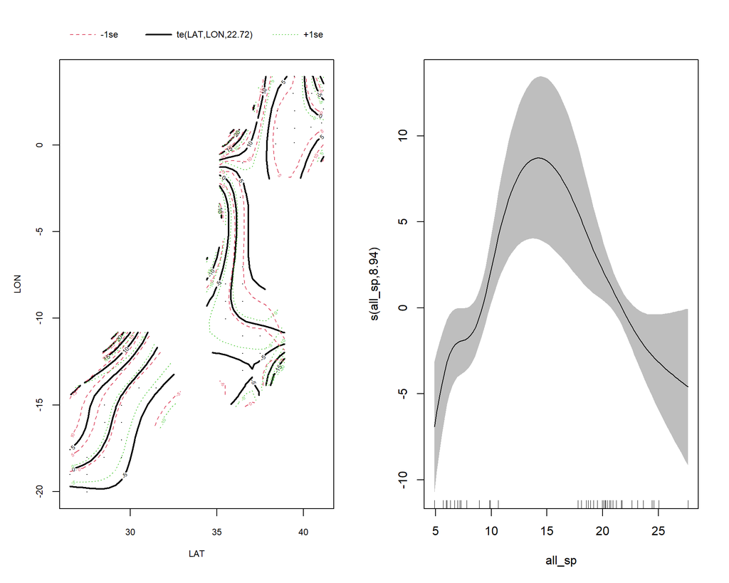

*Figure 4* GAM partial effects of the explanatory variables for (a) the distance to the competitor’s centroid within the isotopic niche space (CCD). Shadowed areas represent 95% confidence intervals around the main effects.

```r
#pdf(file = "GAM/CCD_GAM_dCcorr.pdf", width = 5, height = 5)
par(mfrow = c(1, 2))
plot(CCD_gam, all.terms = T, shade = TRUE, shade.col = "grey", rug = TRUE, seWithMean = TRUE)
```

```r
#dev.off()
```

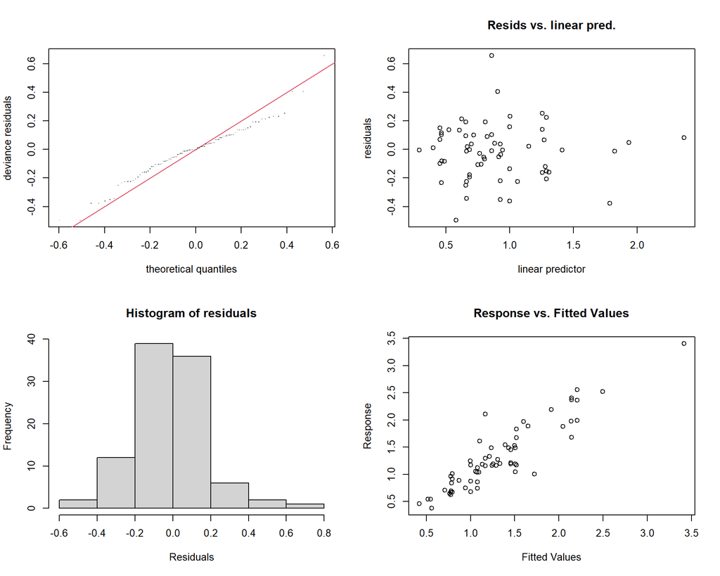

*Figure S4*. Diagnostic plots for the GAMs for the distance to competitor centroids (CCD)

```
#>
#> Method: GCV   Optimizer: outer newton
#> full convergence after 22 iterations.
#> Gradient range [2.679399e-09,3.840236e-08]
#> (score 0.07550749 & scale 0.05103844).
#> Hessian positive definite, eigenvalue range [5.611088e-09,0.000290445].
#> Model rank =  34 / 34
#>
#> Basis dimension (k) checking results. Low p-value (k-index<1) may
#> indicate that k is too low, especially if edf is close to k'.
#>
#>                k'   edf k-index p-value
#> te(LAT,LON) 24.00 22.72    1.10   0.845
#> s(all_sp)    9.00  8.94    0.81   0.015 *
#> ---
#> Signif. codes:  0 '***' 0.001 '**' 0.01 '*' 0.05 '.' 0.1 ' ' 1
```

```r
#png("GAM/CCD_dCcorr_gamcheck.png", res = 100, width = 600, height = 600)
par(mfrow = c(2, 2))
gam.check(CCD_gam)
```

```r
#dev.off()
```

# 3 Mixing Models

We ran species-specific **Bayesian Stable Isotope Mixing Models (BSIMM)** based on δ15N and δ13C values to estimate the relative contribution of the potential prey items in the diet of the three species.

The convergence of models was checked using *Gelman-Rubin* and *Geweke* diagnostics (Stock et al., 2018; Stock and Semmens, 2016).

The **diet-tissue discrimination factors (DTDF)** were estimated following Caut et al. (2009) (Table S1).

**Prey groups** were selected to represent the main potential prey in the diet of the three species (see Table S2)

The appropriate parameterization of the BSIMM was validated through the simulation of **mixing polygons**, where all consumer data corrected for DTDFs should fall within the bounds of the mixing space (Phillips et al., 2014; Smith et al., 2013).

```r
its <- 1500  #specify the number of iterations ("its")
min_C <- -22  #specify the dimensions and resolution for the mixing region figure
max_C <- -14    #choose values outside the 95% mixing region
min_N <- 5
max_N <- 17
res <- 250 #resolution of the mixing region figure; reducing this improves performance

##Now RUN the simulation
step_C <- (max_C - min_C)/(res - 1)
step_N <- (max_N - min_N)/(res - 1)
C_g <- seq(min_C,max_C,by=step_C) #values must be in ascending order
N_g <- seq(min_N,max_N,by=step_N) #values must be in ascending order
mgrid <- function(a,b) {  #create a grid of values to test for P-I-P
  list(
    x=outer(b*0,a,FUN="+"),
    y=outer(b,a*0,FUN="+")
  )
}
m <- mgrid(C_g,N_g)
```

We will run one model for each area and each species:

## 3.1 Canarias

### 3.1.1 SWO

> Mixing Polygons

```r
samples <- samples %>%  st_drop_geometry()

sources <- read.table("SIA/MixSIAR/INPUT/prey_sourcesCAN.csv",header=T,sep=",") %>%
  dplyr::select(-Source, -n)  #always put 13C(x) before 15N(y)

canarias <- samples %>%
  filter(Area1 == "Canarias" & Species == "SWO") %>%
  select(dC_corr, dN, FL)

mixture = as.data.frame(canarias[,1:2])

TEF <-  read.table("SIA/MixSIAR/INPUT/df_SWO.csv", header=T,sep=",") %>%
  dplyr::select(-Source)

Par_values <- array(0, c(its,(nrow(sources)*4+3)))  #create files to store data
p <- array(0, c(its,(nrow(mixture))))
mix_reg <- array(0, c(res,res))
for (i in 1:its) {    #run loops to generate source isotopic signatures, for iterations = 'its'
  v <- array(0, c(nrow(sources),2))
  f <- array(0, c(nrow(TEF),2))
  for (j in 1:nrow(sources)) {
    v[j,1] <- rnorm(1, mean=sources[j,1], sd=sources[j,2])  #generate values from norm. dist. for d13C
    v[j,2] <- rnorm(1, mean=sources[j,3], sd=sources[j,4])  #generate values from norm. dist. for d15N
    f[j,1] <- rnorm(1, mean=TEF[j,1], sd=TEF[j,2])  #generate values from norm. dist. for d13C enrichment
    f[j,2] <- rnorm(1, mean=TEF[j,3], sd=TEF[j,4])  #generate values from norm. dist. for d15N enrichment
  }
  V <- v+f
  hull <- chull(V)  #create a 2D convex hull from the enriched sources
  hull_a <- append(hull,hull[1])  #closes the polygon
  P <- point.in.polygon(mixture[,1], mixture[,2], V[hull_a,1], V[hull_a,2]) #calculate P_I_P
  P_n <- as.numeric(P)
  p[i,] <- P_n
  poly_a <- areapl(V[hull_a,])  #calculate polygon area, for evaluating the quantity of iterations
  m$y_f <- m$y[res:1,]  #flip y grid data to resemble axes (d13C=x, d15N=y)
  m_r <- point.in.polygon(m$x, m$y_f, V[hull_a,1], V[hull_a,2]) #calculate P-I-P for the mixing region
  m_r_s <- matrix(m_r,nrow=res,byrow=F)  #convert vector into square matrix
  m_r_s[m_r_s > 1] <- 1  #point.in.polygon can return '2' or '3'
  mix_reg <- mix_reg + m_r_s
  vals <- c(v[,1],v[,2],f[,1],f[,2],0,0,0)  #concatenate values for this iteration
  Par_values[i,] <- vals  #store values
  Par_values[i,ncol(Par_values)-2] <- poly_a
  Par_values[i,ncol(Par_values)-1] <- i
  Par_values[i,ncol(Par_values)] <- var(Par_values[1:i,ncol(Par_values)-2])
  if (i %% 10 ==0) cat(paste("iteration", i, "\n"))
}

p[p > 1] <- 1   #point.in.polygon can return '2' or '3'
Probabilities <- colSums(p)/its
#print(Probabilities>0.05)
P <- ifelse(Probabilities>0.05, 1, 0)
sum(P/nrow(mixture)*100)
sum(P)
```

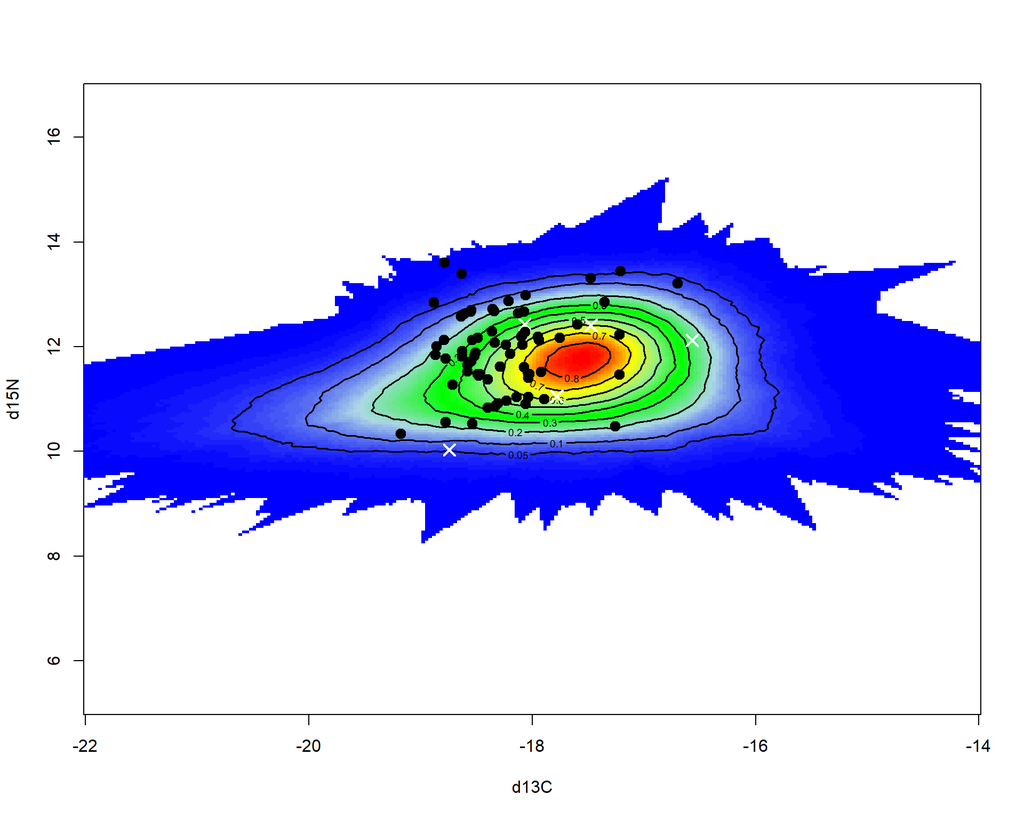

mixing region, consumers, average enriched source signatures

```r
mix_reg <- mix_reg/its  #convert to 0-1 scale
mix_reg[mix_reg==0] <- NA #make the zeros white
mix_regt <- t(mix_reg[ncol(mix_reg):1,])  #transpose matrix for use with 'image'

image(C_g, N_g, mix_regt, col=colorRampPalette(c("blue", "light blue", "green", "light green",
             "yellow", "red"))(100), xlab="d13C", ylab="d15N", useRaster=T)
cont <- c(0.05, seq(0.1, 1, by=0.1))
contour(C_g, N_g, mix_regt, levels=cont, add=TRUE, drawlabels=T, lwd=1.9)
sources_TEF <- sources + TEF
points(sources_TEF[,1], sources_TEF[,3], col="white", pch=4, lwd=2, cex=1.5)
points(mixture, pch=19, cex=1.3)
```

Delete points outside 95% interval

```r
mixture$insidepolygon95 <- P
can_filtered <- merge(canarias, mixture, by = c("dC_corr", "dN")) %>%
  dplyr:: filter(insidepolygon95 == 1)  %>%
  dplyr:: select(dC_corr, dN, FL)

write.table(can_filtered, "SIA/MixSIAR/INPUT/swocan_filtered.csv", append = F, sep = ",", dec = ".", row.names = F, col.names = TRUE)
```

> MixSIAR

```r
## Load mix data
mix.filename <- "SIA/MixSIAR/INPUT/swocan_filtered.csv"
mix <- load_mix_data(filename=mix.filename,
   iso_names=c("dC_corr","dN"),
   factors= NULL,
   fac_random=NULL,
   fac_nested=NULL,
   cont_effects=NULL)

## Load source data
source.filename <- "SIA/MixSIAR/INPUT/prey_sourcesCAN.csv"
source <- load_source_data(filename=source.filename,
         source_factors=NULL,
         conc_dep=FALSE,
         data_type="means",
         mix)

## Load discrimination data
discr.filename <- "SIA/MixSIAR/INPUT/df_SWO.csv"
discr <- load_discr_data(filename=discr.filename,
       mix)
```

Define model structure and write JAGS model file

```r
model_filename <- "SIA/MixSIAR/MixSIAR_model_SWO_CAN.txt"   # Name of the JAGS model file
resid_err <- TRUE
process_err <- TRUE
write_JAGS_model(model_filename, resid_err, process_err, mix, source)

## Run the JAGS model
a=Sys.time()
jags.uninf <- run_model(run="extreme",mix,source,discr,model_filename,alpha.prior = 1, resid_err, process_err)
Sys.time()-a

## Process diagnostics, summary stats, and posterior plots
output_JAGS(jags.uninf, mix, source,
      output_options = list(summary_save = TRUE, summary_name = "SIA/MixSIAR/summary_statistics_swo_can",
          sup_post = FALSE, plot_post_save_pdf = F, plot_post_name = "",
          sup_pairs = F, plot_pairs_save_pdf =F, plot_pairs_name = "",
          sup_xy= F, plot_xy_save_pdf = F, plot_xy_name = "",
          gelman = TRUE, heidel = FALSE, geweke = TRUE,
          diag_save = T, diag_name = "SIA/MixSIAR/diagnostics_swo_can",
          indiv_effect = FALSE, plot_post_save_png = FALSE, plot_pairs_save_png = F, plot_xy_save_png = FALSE, diag_save_ggmcmc = TRUE))

save(jags.uninf, file = "SIA/MixSIAR/swo_can.RData")
```

### 3.1.2 PGO

> MixingPolygons

```r
##USER INPUT
sources <- read.table("SIA/MixSIAR/INPUT/prey_sourcesCAN_sharks.csv",header=T,sep=",") %>%
  dplyr::select(-Source, -n)  #always put 13C(x) before 15N(y)

canarias <- samples %>%
  filter(Area1 == "Canarias" & Species == "PGO") %>%
  select(dC_corr, dN)

mixture = as.data.frame(canarias)

TEF <-  read.table("SIA/MixSIAR/INPUT/df_PGO.csv", header=T,sep=",") %>%
  dplyr::select(-Source)

Par_values <- array(0, c(its,(nrow(sources)*4+3)))  #create files to store data
p <- array(0, c(its,(nrow(mixture))))
mix_reg <- array(0, c(res,res))
for (i in 1:its) {    #run loops to generate source isotopic signatures, for iterations = 'its'
  v <- array(0, c(nrow(sources),2))
  f <- array(0, c(nrow(TEF),2))
  for (j in 1:nrow(sources)) {
    v[j,1] <- rnorm(1, mean=sources[j,1], sd=sources[j,2])  #generate values from norm. dist. for d13C
    v[j,2] <- rnorm(1, mean=sources[j,3], sd=sources[j,4])  #generate values from norm. dist. for d15N
    f[j,1] <- rnorm(1, mean=TEF[j,1], sd=TEF[j,2])  #generate values from norm. dist. for d13C enrichment
    f[j,2] <- rnorm(1, mean=TEF[j,3], sd=TEF[j,4])  #generate values from norm. dist. for d15N enrichment
  }
  V <- v+f
  hull <- chull(V)  #create a 2D convex hull from the enriched sources
  hull_a <- append(hull,hull[1])  #closes the polygon
  P <- point.in.polygon(mixture[,1], mixture[,2], V[hull_a,1], V[hull_a,2]) #calculate P_I_P
  P_n <- as.numeric(P)
  p[i,] <- P_n
  poly_a <- areapl(V[hull_a,])  #calculate polygon area, for evaluating the quantity of iterations
  m$y_f <- m$y[res:1,]  #flip y grid data to resemble axes (d13C=x, d15N=y)
  m_r <- point.in.polygon(m$x, m$y_f, V[hull_a,1], V[hull_a,2]) #calculate P-I-P for the mixing region
  m_r_s <- matrix(m_r,nrow=res,byrow=F)  #convert vector into square matrix
  m_r_s[m_r_s > 1] <- 1  #point.in.polygon can return '2' or '3'
  mix_reg <- mix_reg + m_r_s
  vals <- c(v[,1],v[,2],f[,1],f[,2],0,0,0)  #concatenate values for this iteration
  Par_values[i,] <- vals  #store values
  Par_values[i,ncol(Par_values)-2] <- poly_a
  Par_values[i,ncol(Par_values)-1] <- i
  Par_values[i,ncol(Par_values)] <- var(Par_values[1:i,ncol(Par_values)-2])
  if (i %% 10 ==0) cat(paste("iteration", i, "\n"))
}

##FIGURE 2: proportion of iterations that each consumer was inside mixing polygon
p[p > 1] <- 1   #point.in.polygon can return '2' or '3'
Probabilities <- colSums(p)/its
#print(Probabilities>0.05)
P <- ifelse(Probabilities>0.05, 1, 0)
sum(P/nrow(mixture)*100)
sum(P)
```

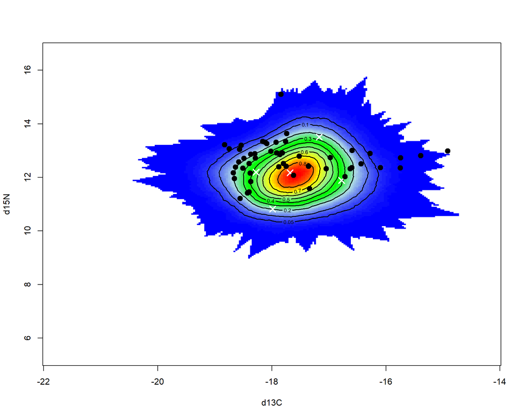

mixing region, consumers, average enriched source signatures

```r
##FIGURE 3:
mix_reg <- mix_reg/its  #convert to 0-1 scale
mix_reg[mix_reg==0] <- NA #make the zeros white
mix_regt <- t(mix_reg[ncol(mix_reg):1,])  #transpose matrix for use with 'image'


image(C_g, N_g, mix_regt, col=colorRampPalette(c("blue", "light blue", "green", "light green",
             "yellow", "red"))(100), xlab="d13C", ylab="d15N", useRaster=T)
cont <- c(0.05, seq(0.1, 1, by=0.1))
contour(C_g, N_g, mix_regt, levels=cont, add=TRUE, drawlabels=T, lwd=1.9)
sources_TEF <- sources + TEF
points(sources_TEF[,1], sources_TEF[,3], col="white", pch=4, lwd=2, cex=1.5)
points(mixture, pch=19, cex=1.3)
```

Delete points outside 95% interval

```r
mixture$insidepolygon95 <- P

can_filtered <- merge(canarias, mixture, by = c("dC_corr", "dN")) %>%
  dplyr:: filter(insidepolygon95 == 1)  %>%
  dplyr:: select(dC_corr, dN)

write.table(can_filtered, "SIA/MixSIAR/INPUT/pgocan_filtered.csv", append = F, sep = ",", dec = ".", row.names = F, col.names = TRUE)
```

> MixSIAR

```r
## Load mix data
mix.filename <- "SIA/MixSIAR/INPUT/pgocan_filtered.csv"
mix <- load_mix_data(filename=mix.filename,
   iso_names=c("dC_corr","dN"),
   factors= NULL,
   fac_random=NULL,
   fac_nested=NULL,
   cont_effects=NULL)

## Load source data
source.filename <- "SIA/MixSIAR/INPUT/prey_sourcesCAN_sharks.csv"
source <- load_source_data(filename=source.filename,
         source_factors=NULL,
         conc_dep=FALSE,
         data_type="means",
         mix)

## Load discrimination data
discr.filename <- "SIA/MixSIAR/INPUT/df_PGO.csv"
discr <- load_discr_data(filename=discr.filename,
       mix)
```

Define model structure and write JAGS model file

```r
model_filename <- "SIA/MixSIAR/MixSIAR_model_PGO_CAN.txt"   # Name of the JAGS model file
resid_err <- TRUE
process_err <- TRUE
write_JAGS_model(model_filename, resid_err, process_err, mix, source)

## Run the JAGS model
a=Sys.time()
jags.uninf <- run_model(run="extreme",mix,source,discr,model_filename,alpha.prior = 1, resid_err, process_err)
Sys.time()-a
## Process diagnostics, summary stats, and posterior plots
output_JAGS(jags.uninf, mix, source,
      output_options = list(summary_save = TRUE, summary_name = "SIA/MixSIAR/summary_statistics_PGOcan",
          sup_post = FALSE, plot_post_save_pdf = F, plot_post_name = "",
          sup_pairs = F, plot_pairs_save_pdf =F, plot_pairs_name = "",
          sup_xy= F, plot_xy_save_pdf = F, plot_xy_name = "",
          gelman = TRUE, heidel = FALSE, geweke = TRUE,
          diag_save = T, diag_name = "SIA/MixSIAR/diagnostics_PGOcan",
          indiv_effect = FALSE, plot_post_save_png = FALSE, plot_pairs_save_png = F, plot_xy_save_png = FALSE, diag_save_ggmcmc = TRUE))

save(jags.uninf, file = "SIA/MixSIAR/PGO_can.RData")
```

### 3.1.3 IOO

> MixingPolygons

```r
##USER INPUT
sources <- read.table("SIA/MixSIAR/INPUT/prey_sourcesCAN_sharks.csv",header=T,sep=",") %>%
  dplyr::select(-Source, -n)  #always put 13C(x) before 15N(y)

canarias <- samples %>%
  filter(Area1 == "Canarias" & Species == "IOO") %>%
  select(dC_corr, dN)

mixture = as.data.frame(canarias)

TEF <-  read.table("SIA/MixSIAR/INPUT/df_IOO.csv", header=T,sep=",") %>%
  dplyr::select(-Source)

Par_values <- array(0, c(its,(nrow(sources)*4+3)))  #create files to store data
p <- array(0, c(its,(nrow(mixture))))
mix_reg <- array(0, c(res,res))
for (i in 1:its) {    #run loops to generate source isotopic signatures, for iterations = 'its'
  v <- array(0, c(nrow(sources),2))
  f <- array(0, c(nrow(TEF),2))
  for (j in 1:nrow(sources)) {
    v[j,1] <- rnorm(1, mean=sources[j,1], sd=sources[j,2])  #generate values from norm. dist. for d13C
    v[j,2] <- rnorm(1, mean=sources[j,3], sd=sources[j,4])  #generate values from norm. dist. for d15N
    f[j,1] <- rnorm(1, mean=TEF[j,1], sd=TEF[j,2])  #generate values from norm. dist. for d13C enrichment
    f[j,2] <- rnorm(1, mean=TEF[j,3], sd=TEF[j,4])  #generate values from norm. dist. for d15N enrichment
  }
  V <- v+f
  hull <- chull(V)  #create a 2D convex hull from the enriched sources
  hull_a <- append(hull,hull[1])  #closes the polygon
  P <- point.in.polygon(mixture[,1], mixture[,2], V[hull_a,1], V[hull_a,2]) #calculate P_I_P
  P_n <- as.numeric(P)
  p[i,] <- P_n
  poly_a <- areapl(V[hull_a,])  #calculate polygon area, for evaluating the quantity of iterations
  m$y_f <- m$y[res:1,]  #flip y grid data to resemble axes (d13C=x, d15N=y)
  m_r <- point.in.polygon(m$x, m$y_f, V[hull_a,1], V[hull_a,2]) #calculate P-I-P for the mixing region
  m_r_s <- matrix(m_r,nrow=res,byrow=F)  #convert vector into square matrix
  m_r_s[m_r_s > 1] <- 1  #point.in.polygon can return '2' or '3'
  mix_reg <- mix_reg + m_r_s
  vals <- c(v[,1],v[,2],f[,1],f[,2],0,0,0)  #concatenate values for this iteration
  Par_values[i,] <- vals  #store values
  Par_values[i,ncol(Par_values)-2] <- poly_a
  Par_values[i,ncol(Par_values)-1] <- i
  Par_values[i,ncol(Par_values)] <- var(Par_values[1:i,ncol(Par_values)-2])
  if (i %% 10 ==0) cat(paste("iteration", i, "\n"))
}

##FIGURE 2: proportion of iterations that each consumer was inside mixing polygon
p[p > 1] <- 1   #point.in.polygon can return '2' or '3'
Probabilities <- colSums(p)/its
#print(Probabilities>0.05)
P <- ifelse(Probabilities>0.05, 1, 0)
sum(P/nrow(mixture)*100)
sum(P)
```

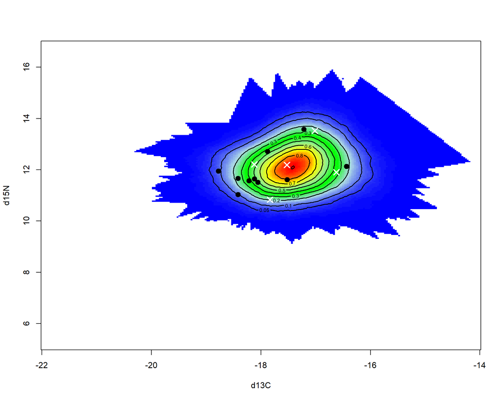

mixing region, consumers, average enriched source signatures

```r
mix_reg <- mix_reg/its  #convert to 0-1 scale
mix_reg[mix_reg==0] <- NA #make the zeros white
mix_regt <- t(mix_reg[ncol(mix_reg):1,])  #transpose matrix for use with 'image'

image(C_g, N_g, mix_regt, col=colorRampPalette(c("blue", "light blue", "green", "light green", "yellow", "red"))(100), xlab="d13C", ylab="d15N", useRaster=T)
cont <- c(0.05, seq(0.1, 1, by=0.1))
contour(C_g, N_g, mix_regt, levels=cont, add=TRUE, drawlabels=T, lwd=1.9)
sources_TEF <- sources + TEF
points(sources_TEF[,1], sources_TEF[,3], col="white", pch=4, lwd=2, cex=1.5)
points(mixture, pch=19, cex=1.3)
```

```r
#dev.copy2pdf(file="SIA/OUTPUT/Mix_RegionCAN.pdf")
```

delete points outside 95% interval

```r
mixture$insidepolygon95 <- P

can_filtered <- merge(canarias, mixture, by = c("dC_corr", "dN")) %>%
  dplyr:: filter(insidepolygon95 == 1)  %>%
  dplyr:: select(dC_corr, dN)

write.table(can_filtered, "SIA/MixSIAR/INPUT/ioocan_filtered.csv", append = F, sep = ",", dec = ".", row.names = F, col.names = TRUE)
```

> MixSIAR

```r
## Load mix data
mix.filename <- "SIA/MixSIAR/INPUT/ioocan_filtered.csv"
mix <- load_mix_data(filename=mix.filename,
   iso_names=c("dC_corr","dN"),
   factors= NULL,
   fac_random=NULL,
   fac_nested=NULL,
   cont_effects=NULL)

## Load source data
source.filename <- "SIA/MixSIAR/INPUT/prey_sourcesCAN_sharks.csv"
source <- load_source_data(filename=source.filename,
         source_factors=NULL,
         conc_dep=FALSE,
         data_type="means",
         mix)

## Load discrimination data
discr.filename <- "SIA/MixSIAR/INPUT/df_IOO.csv"
discr <- load_discr_data(filename=discr.filename,
       mix)
```

Define model structure and write JAGS model file

```r
model_filename <- "SIA/MixSIAR/MixSIAR_model_IOO_CAN.txt"   # Name of the JAGS model file
resid_err <- TRUE
process_err <- TRUE
write_JAGS_model(model_filename, resid_err, process_err, mix, source)

## Run the JAGS model
a=Sys.time()
jags.uninf <- run_model(run="extreme",mix,source,discr,model_filename,alpha.prior = 1, resid_err, process_err)
Sys.time()-a
## Process diagnostics, summary stats, and posterior plots
output_JAGS(jags.uninf, mix, source,
      output_options = list(summary_save = TRUE, summary_name = "SIA/MixSIAR/summary_statistics_IOOcan",
          sup_post = FALSE, plot_post_save_pdf = F, plot_post_name = "",
          sup_pairs = F, plot_pairs_save_pdf =F, plot_pairs_name = "",
          sup_xy= F, plot_xy_save_pdf = F, plot_xy_name = "",
          gelman = TRUE, heidel = FALSE, geweke = TRUE,
          diag_save = T, diag_name = "SIA/MixSIAR/diagnostics_IOOcan",
          indiv_effect = FALSE, plot_post_save_png = FALSE, plot_pairs_save_png = F, plot_xy_save_png = FALSE, diag_save_ggmcmc = TRUE))

save(jags.uninf, file = "SIA/MixSIAR/IOO_can.RData")
```

## 3.2 Portugal

### 3.2.1 SWO

> MixingPolygons

```r
##USER INPUT
sources <- read.table("SIA/MixSIAR/INPUT/prey_sourcesGCZ.csv",header=T,sep=",") %>%
  dplyr::select(-Source, -n)  #always put 13C(x) before 15N(y)

portugal <- samples %>%
  filter(Area1 == "Sur Portugal" & Species == "SWO") %>%
  dplyr::select(dC_corr, dN)

mixture = as.data.frame(portugal)

TEF <-  read.table("SIA/MixSIAR/INPUT/df_SWO.csv", header=T,sep=",") %>%
  dplyr::select(-Source)

##Now RUN the simulation
Par_values <- array(0, c(its,(nrow(sources)*4+3)))  #create files to store data
p <- array(0, c(its,(nrow(mixture))))
mix_reg <- array(0, c(res,res))
for (i in 1:its) {    #run loops to generate source isotopic signatures, for iterations = 'its'
  v <- array(0, c(nrow(sources),2))
  f <- array(0, c(nrow(TEF),2))
  for (j in 1:nrow(sources)) {
    v[j,1] <- rnorm(1, mean=sources[j,1], sd=sources[j,2])  #generate values from norm. dist. for d13C
    v[j,2] <- rnorm(1, mean=sources[j,3], sd=sources[j,4])  #generate values from norm. dist. for d15N
    f[j,1] <- rnorm(1, mean=TEF[j,1], sd=TEF[j,2])  #generate values from norm. dist. for d13C enrichment
    f[j,2] <- rnorm(1, mean=TEF[j,3], sd=TEF[j,4])  #generate values from norm. dist. for d15N enrichment
  }
  V <- v+f
  hull <- chull(V)  #create a 2D convex hull from the enriched sources
  hull_a <- append(hull,hull[1])  #closes the polygon
  P <- point.in.polygon(mixture[,1], mixture[,2], V[hull_a,1], V[hull_a,2]) #calculate P_I_P
  P_n <- as.numeric(P)
  p[i,] <- P_n
  poly_a <- areapl(V[hull_a,])  #calculate polygon area, for evaluating the quantity of iterations
  m$y_f <- m$y[res:1,]  #flip y grid data to resemble axes (d13C=x, d15N=y)
  m_r <- point.in.polygon(m$x, m$y_f, V[hull_a,1], V[hull_a,2]) #calculate P-I-P for the mixing region
  m_r_s <- matrix(m_r,nrow=res,byrow=F)  #convert vector into square matrix
  m_r_s[m_r_s > 1] <- 1  #point.in.polygon can return '2' or '3'
  mix_reg <- mix_reg + m_r_s
  vals <- c(v[,1],v[,2],f[,1],f[,2],0,0,0)  #concatenate values for this iteration
  Par_values[i,] <- vals  #store values
  Par_values[i,ncol(Par_values)-2] <- poly_a
  Par_values[i,ncol(Par_values)-1] <- i
  Par_values[i,ncol(Par_values)] <- var(Par_values[1:i,ncol(Par_values)-2])
  if (i %% 10 ==0) cat(paste("iteration", i, "\n"))
}
##FIGURE 2: proportion of iterations that each consumer was inside mixing polygon
p[p > 1] <- 1   #point.in.polygon can return '2' or '3'
Probabilities <- colSums(p)/its
#print(Probabilities>0.05)
P <- ifelse(Probabilities>0.05, 1, 0)
sum(P/nrow(mixture)*100)
sum(P)
```

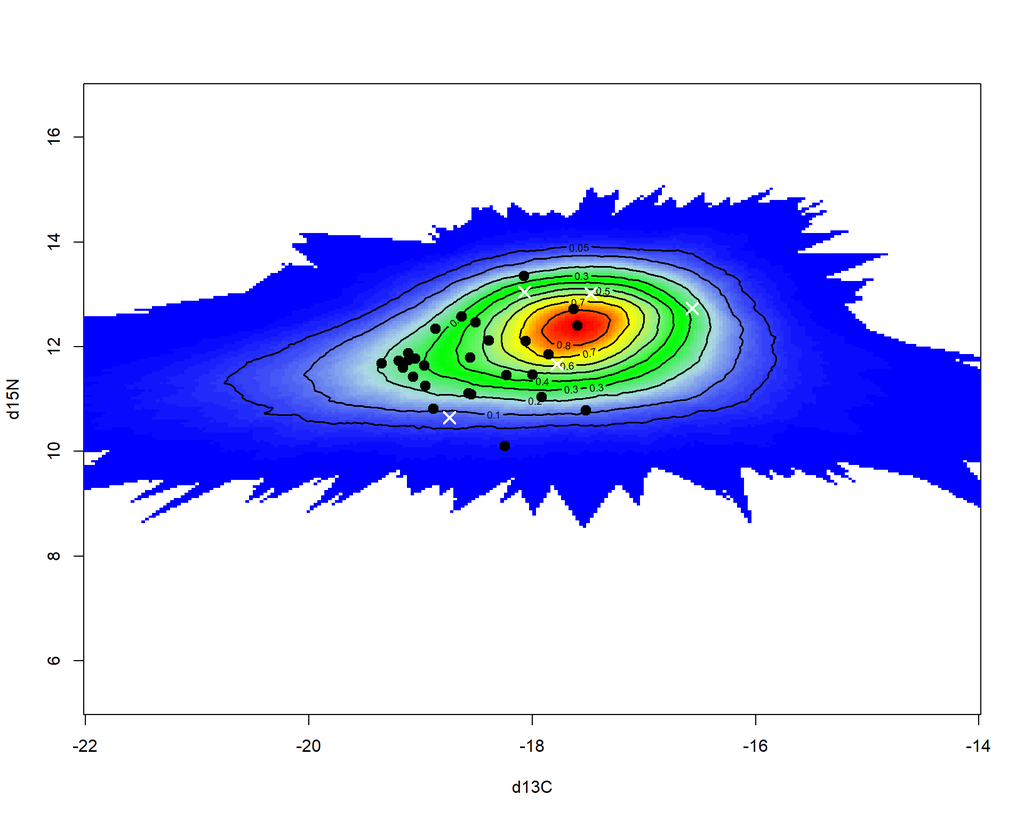

mixing region, consumers, average enriched source signatures

```r
mix_reg <- mix_reg/its  #convert to 0-1 scale
mix_reg[mix_reg==0] <- NA #make the zeros white
mix_regt <- t(mix_reg[ncol(mix_reg):1,])  #transpose matrix for use with 'image'


image(C_g, N_g, mix_regt, col=colorRampPalette(c("blue", "light blue", "green", "light green",
             "yellow", "red"))(100), xlab="d13C", ylab="d15N", useRaster=T)
cont <- c(0.05, seq(0.1, 1, by=0.1))
contour(C_g, N_g, mix_regt, levels=cont, add=TRUE, drawlabels=T, lwd=1.9)
sources_TEF <- sources + TEF
points(sources_TEF[,1], sources_TEF[,3], col="white", pch=4, lwd=2, cex=1.5)
points(mixture, pch=19, cex=1.3)
```

```r
#dev.copy2pdf(file="SIA/OUTPUT/Mix_RegionMED.pdf")
```

delete points outside 95% interval

```r
mixture$insidepolygon95 <- P
gdc_filtered <- merge(portugal, mixture, by = c("dC_corr", "dN")) %>%
  dplyr:: filter(insidepolygon95 == 1)  %>%
  dplyr:: select(dC_corr, dN)

#write.table(gdc_filtered, "SIA/MixSIAR/INPUT/swogdc_filtered.csv", append = F, sep = ",", dec = ".", row.names = F, col.names = TRUE)
```

> MixSIAR

```r
## Load mix data
mix.filename <- "SIA/MixSIAR/INPUT/swogdc_filtered.csv"
mix <- load_mix_data(filename=mix.filename,
   iso_names=c("dC_corr","dN"),
   factors= NULL,
   fac_random=NULL,
   fac_nested=NULL,
   cont_effects=NULL)

## Load source data
source.filename <- "SIA/MixSIAR/INPUT/prey_sourcesGCZ.csv"
source <- load_source_data(filename=source.filename,
         source_factors=NULL,
         conc_dep=FALSE,
         data_type="means",
         mix)

## Load discrimination data
discr.filename <- "SIA/MixSIAR/INPUT/df_SWO.csv"
discr <- load_discr_data(filename=discr.filename,
       mix)
```

Define model structure and write JAGS model file

```r
model_filename <- "SIA/MixSIAR/MixSIAR_model_SWO_GCZ.txt"   # Name of the JAGS model file
resid_err <- TRUE
process_err <- TRUE
write_JAGS_model(model_filename, resid_err, process_err, mix, source)

## Run the JAGS model
a=Sys.time()
jags.uninf <- run_model(run="extreme",mix,source,discr,model_filename,alpha.prior = 1, resid_err, process_err)
Sys.time()-a
## Process diagnostics, summary stats, and posterior plots
output_JAGS(jags.uninf, mix, source,
      output_options = list(summary_save = TRUE, summary_name = "SIA/MixSIAR/summary_statistics_swogdc",
          sup_post = FALSE, plot_post_save_pdf = F, plot_post_name = "",
          sup_pairs = F, plot_pairs_save_pdf =F, plot_pairs_name = "",
          sup_xy= F, plot_xy_save_pdf = F, plot_xy_name = "",
          gelman = TRUE, heidel = FALSE, geweke = TRUE,
          diag_save = T, diag_name = "SIA/MixSIAR/diagnostics_swogdc",
          indiv_effect = FALSE, plot_post_save_png = FALSE, plot_pairs_save_png = F, plot_xy_save_png = FALSE, diag_save_ggmcmc = TRUE))

save(jags.uninf, file = "SIA/MixSIAR/swo_GCZ.RData")
```

### 3.2.2 PGO

> MixingPolygons

```r
##USER INPUT
sources <- read.table("SIA/MixSIAR/INPUT/prey_sourcesGCZ_sharks.csv",header=T,sep=",") %>%
  dplyr::select(-Source, -n)  #always put 13C(x) before 15N(y)

portugal <- samples %>%
  filter(Area1 == "Sur Portugal" & Species == "PGO") %>%
  dplyr::select(dC_corr, dN)

mixture = as.data.frame(portugal)

TEF <-  read.table("SIA/MixSIAR/INPUT/df_PGO.csv", header=T,sep=",") %>%
  dplyr::select(-Source)

##Now RUN the simulation
Par_values <- array(0, c(its,(nrow(sources)*4+3)))  #create files to store data
p <- array(0, c(its,(nrow(mixture))))
mix_reg <- array(0, c(res,res))
for (i in 1:its) {    #run loops to generate source isotopic signatures, for iterations = 'its'
  v <- array(0, c(nrow(sources),2))
  f <- array(0, c(nrow(TEF),2))
  for (j in 1:nrow(sources)) {
    v[j,1] <- rnorm(1, mean=sources[j,1], sd=sources[j,2])  #generate values from norm. dist. for d13C
    v[j,2] <- rnorm(1, mean=sources[j,3], sd=sources[j,4])  #generate values from norm. dist. for d15N
    f[j,1] <- rnorm(1, mean=TEF[j,1], sd=TEF[j,2])  #generate values from norm. dist. for d13C enrichment
    f[j,2] <- rnorm(1, mean=TEF[j,3], sd=TEF[j,4])  #generate values from norm. dist. for d15N enrichment
  }
  V <- v+f
  hull <- chull(V)  #create a 2D convex hull from the enriched sources
  hull_a <- append(hull,hull[1])  #closes the polygon
  P <- point.in.polygon(mixture[,1], mixture[,2], V[hull_a,1], V[hull_a,2]) #calculate P_I_P
  P_n <- as.numeric(P)
  p[i,] <- P_n
  poly_a <- areapl(V[hull_a,])  #calculate polygon area, for evaluating the quantity of iterations
  m$y_f <- m$y[res:1,]  #flip y grid data to resemble axes (d13C=x, d15N=y)
  m_r <- point.in.polygon(m$x, m$y_f, V[hull_a,1], V[hull_a,2]) #calculate P-I-P for the mixing region
  m_r_s <- matrix(m_r,nrow=res,byrow=F)  #convert vector into square matrix
  m_r_s[m_r_s > 1] <- 1  #point.in.polygon can return '2' or '3'
  mix_reg <- mix_reg + m_r_s
  vals <- c(v[,1],v[,2],f[,1],f[,2],0,0,0)  #concatenate values for this iteration
  Par_values[i,] <- vals  #store values
  Par_values[i,ncol(Par_values)-2] <- poly_a
  Par_values[i,ncol(Par_values)-1] <- i
  Par_values[i,ncol(Par_values)] <- var(Par_values[1:i,ncol(Par_values)-2])
  if (i %% 10 ==0) cat(paste("iteration", i, "\n"))
}

##FIGURE 2: proportion of iterations that each consumer was inside mixing polygon
p[p > 1] <- 1   #point.in.polygon can return '2' or '3'
Probabilities <- colSums(p)/its
#print(Probabilities>0.05)
P <- ifelse(Probabilities>0.05, 1, 0)
sum(P/nrow(mixture)*100)
sum(P)
```

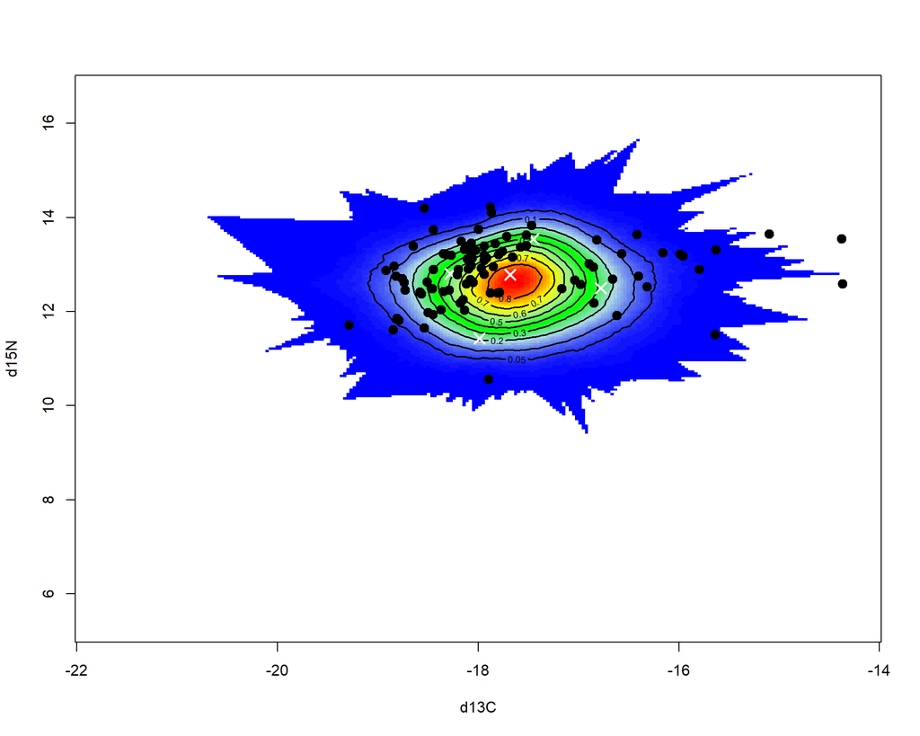

mixing region, consumers, average enriched source signatures

```r
##FIGURE 3: mixing region, consumers, average enriched source signatures
mix_reg <- mix_reg/its  #convert to 0-1 scale
mix_reg[mix_reg==0] <- NA #make the zeros white
mix_regt <- t(mix_reg[ncol(mix_reg):1,])  #transpose matrix for use with 'image'


image(C_g, N_g, mix_regt, col=colorRampPalette(c("blue", "light blue", "green", "light green",
             "yellow", "red"))(100), xlab="d13C", ylab="d15N", useRaster=T)
cont <- c(0.05, seq(0.1, 1, by=0.1))
contour(C_g, N_g, mix_regt, levels=cont, add=TRUE, drawlabels=T, lwd=1.9)
sources_TEF <- sources + TEF
points(sources_TEF[,1], sources_TEF[,3], col="white", pch=4, lwd=2, cex=1.5)
points(mixture, pch=19, cex=1.3)
```

```r
#dev.copy2pdf(file="SIA/OUTPUT/Mix_RegionGCZ.pdf")
```

```r
## delete points outside 95% interval #####
mixture$insidepolygon95 <- P

gdc_filtered <- merge(portugal, mixture, by = c("dC_corr", "dN")) %>%
  dplyr:: filter(insidepolygon95 == 1)  %>%
  dplyr:: select(dC_corr, dN)

write.table(gdc_filtered, "SIA/MixSIAR/INPUT/pgogdc_filtered.csv", append = F, sep = ",", dec = ".", row.names = F, col.names = TRUE)
```

> MixSIAR

```r
## Load mix data
mix.filename <- "SIA/MixSIAR/INPUT/pgogdc_filtered.csv"
mix <- load_mix_data(filename=mix.filename,
   iso_names=c("dC_corr","dN"),
   factors= NULL,
   fac_random=NULL,
   fac_nested=NULL,
   cont_effects=NULL)

## Load source data
source.filename <- "SIA/MixSIAR/INPUT/prey_sourcesGCZ_sharks.csv"
source <- load_source_data(filename=source.filename,
         source_factors=NULL,
         conc_dep=FALSE,
         data_type="means",
         mix)

## Load discrimination data
discr.filename <- "SIA/MixSIAR/INPUT/df_PGO.csv"
discr <- load_discr_data(filename=discr.filename,
       mix)
```

Define model structure and write JAGS model file

```r
model_filename <- "SIA/MixSIAR/MixSIAR_model_PGO_GCZ.txt"   # Name of the JAGS model file
resid_err <- TRUE
process_err <- TRUE
write_JAGS_model(model_filename, resid_err, process_err, mix, source)

## Run the JAGS model
a=Sys.time()
jags.uninf <- run_model(run="extreme",mix,source,discr,model_filename,alpha.prior = 1, resid_err, process_err)
Sys.time()-a
## Process diagnostics, summary stats, and posterior plots
output_JAGS(jags.uninf, mix, source,
      output_options = list(summary_save = TRUE, summary_name = "SIA/MixSIAR/summary_statistics_PGOgdc",
          sup_post = FALSE, plot_post_save_pdf = F, plot_post_name = "",
          sup_pairs = F, plot_pairs_save_pdf =F, plot_pairs_name = "",
          sup_xy= F, plot_xy_save_pdf = F, plot_xy_name = "",
          gelman = TRUE, heidel = FALSE, geweke = TRUE,
          diag_save = T, diag_name = "SIA/MixSIAR/diagnostics_PGOgdc",
          indiv_effect = FALSE, plot_post_save_png = FALSE, plot_pairs_save_png = F, plot_xy_save_png = FALSE, diag_save_ggmcmc = TRUE))

save(jags.uninf, file = "SIA/MixSIAR/PGO_GCZ.RData")
```

### 3.2.3 IOO

> MixingPolygons

```r
##USER INPUT
sources <- read.table("SIA/MixSIAR/INPUT/prey_sourcesGCZ_sharks.csv",header=T,sep=",") %>%
  dplyr::select(-Source, -n)  #always put 13C(x) before 15N(y)

portugal <- samples %>%
  filter(Area1 == "Sur Portugal" & Species == "IOO") %>%
  dplyr::select(dC_corr, dN)

mixture = as.data.frame(portugal)

TEF <-  read.table("SIA/MixSIAR/INPUT/df_IOO.csv", header=T,sep=",") %>%
  dplyr::select(-Source)

##Now RUN the simulation
Par_values <- array(0, c(its,(nrow(sources)*4+3)))  #create files to store data
p <- array(0, c(its,(nrow(mixture))))
mix_reg <- array(0, c(res,res))
for (i in 1:its) {    #run loops to generate source isotopic signatures, for iterations = 'its'
  v <- array(0, c(nrow(sources),2))
  f <- array(0, c(nrow(TEF),2))
  for (j in 1:nrow(sources)) {
    v[j,1] <- rnorm(1, mean=sources[j,1], sd=sources[j,2])  #generate values from norm. dist. for d13C
    v[j,2] <- rnorm(1, mean=sources[j,3], sd=sources[j,4])  #generate values from norm. dist. for d15N
    f[j,1] <- rnorm(1, mean=TEF[j,1], sd=TEF[j,2])  #generate values from norm. dist. for d13C enrichment
    f[j,2] <- rnorm(1, mean=TEF[j,3], sd=TEF[j,4])  #generate values from norm. dist. for d15N enrichment
  }
  V <- v+f
  hull <- chull(V)  #create a 2D convex hull from the enriched sources
  hull_a <- append(hull,hull[1])  #closes the polygon
  P <- point.in.polygon(mixture[,1], mixture[,2], V[hull_a,1], V[hull_a,2]) #calculate P_I_P
  P_n <- as.numeric(P)
  p[i,] <- P_n
  poly_a <- areapl(V[hull_a,])  #calculate polygon area, for evaluating the quantity of iterations
  m$y_f <- m$y[res:1,]  #flip y grid data to resemble axes (d13C=x, d15N=y)
  m_r <- point.in.polygon(m$x, m$y_f, V[hull_a,1], V[hull_a,2]) #calculate P-I-P for the mixing region
  m_r_s <- matrix(m_r,nrow=res,byrow=F)  #convert vector into square matrix
  m_r_s[m_r_s > 1] <- 1  #point.in.polygon can return '2' or '3'
  mix_reg <- mix_reg + m_r_s
  vals <- c(v[,1],v[,2],f[,1],f[,2],0,0,0)  #concatenate values for this iteration
  Par_values[i,] <- vals  #store values
  Par_values[i,ncol(Par_values)-2] <- poly_a
  Par_values[i,ncol(Par_values)-1] <- i
  Par_values[i,ncol(Par_values)] <- var(Par_values[1:i,ncol(Par_values)-2])
  if (i %% 10 ==0) cat(paste("iteration", i, "\n"))
}

##FIGURE 2: proportion of iterations that each consumer was inside mixing polygon
p[p > 1] <- 1   #point.in.polygon can return '2' or '3'
Probabilities <- colSums(p)/its
#print(Probabilities>0.05)
P <- ifelse(Probabilities>0.05, 1, 0)
sum(P/nrow(mixture)*100)
sum(P)
```

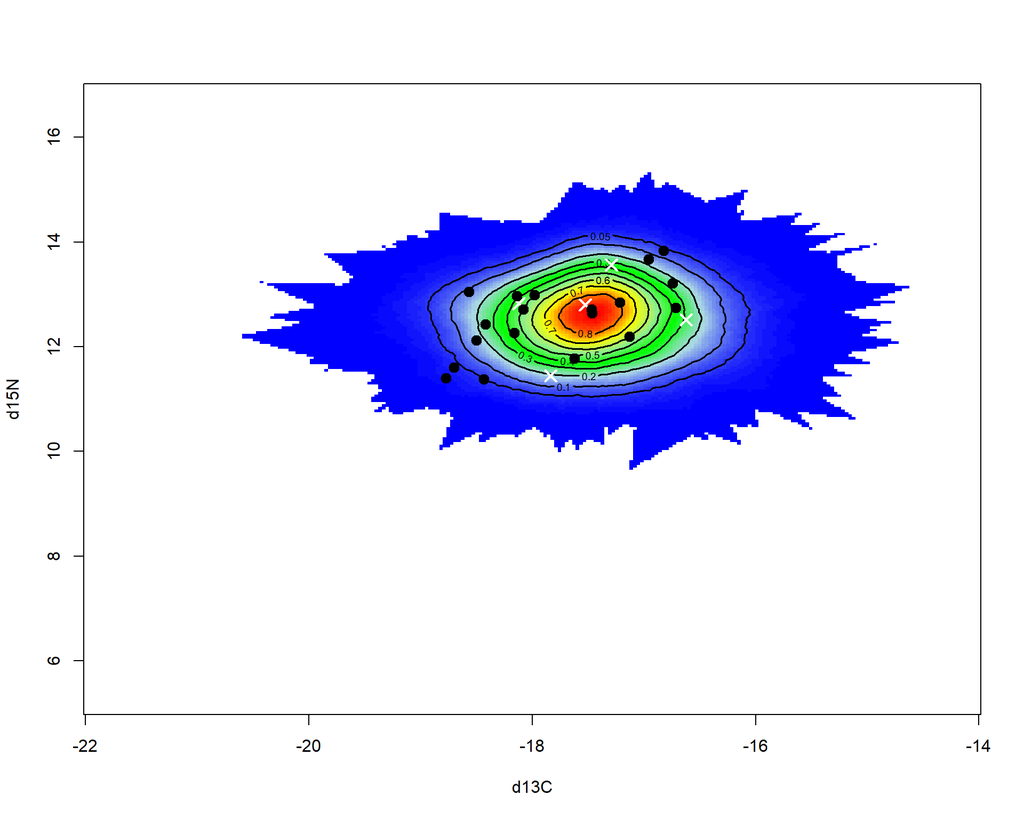

mixing region, consumers, average enriched source signatures

```r
##FIGURE 3: mixing region, consumers, average enriched source signatures
mix_reg <- mix_reg/its  #convert to 0-1 scale
mix_reg[mix_reg==0] <- NA #make the zeros white
mix_regt <- t(mix_reg[ncol(mix_reg):1,])  #transpose matrix for use with 'image'


image(C_g, N_g, mix_regt, col=colorRampPalette(c("blue", "light blue", "green", "light green",
             "yellow", "red"))(100), xlab="d13C", ylab="d15N", useRaster=T)
cont <- c(0.05, seq(0.1, 1, by=0.1))
contour(C_g, N_g, mix_regt, levels=cont, add=TRUE, drawlabels=T, lwd=1.9)
sources_TEF <- sources + TEF
points(sources_TEF[,1], sources_TEF[,3], col="white", pch=4, lwd=2, cex=1.5)
points(mixture, pch=19, cex=1.3)
```

```r
#dev.copy2pdf(file="SIA/OUTPUT/Mix_RegionGCZ.pdf")
```

delete points outside 95% interval

```r
mixture$insidepolygon95 <- P

gdc_filtered <- merge(portugal, mixture, by = c("dC_corr", "dN")) %>%
  dplyr:: filter(insidepolygon95 == 1)  %>%
  dplyr:: select(dC_corr, dN)

write.table(gdc_filtered, "SIA/MixSIAR/INPUT/ioogdc_filtered.csv", append = F, sep = ",", dec = ".", row.names = F, col.names = TRUE)
```

> MixSIAR

```r
## Load mix data
mix.filename <- "SIA/MixSIAR/INPUT/ioogdc_filtered.csv"
mix <- load_mix_data(filename=mix.filename,
   iso_names=c("dC_corr","dN"),
   factors= NULL,
   fac_random=NULL,
   fac_nested=NULL,
   cont_effects=NULL)

## Load source data
source.filename <- "SIA/MixSIAR/INPUT/prey_sourcesGCZ_sharks.csv"
source <- load_source_data(filename=source.filename,
         source_factors=NULL,
         conc_dep=FALSE,
         data_type="means",
         mix)

## Load discrimination data
discr.filename <- "SIA/MixSIAR/INPUT/df_IOO.csv"
discr <- load_discr_data(filename=discr.filename,
       mix)
```

Define model structure and write JAGS model file

```r
model_filename <- "SIA/MixSIAR/MixSIAR_model_IOO_GCZ.txt"   # Name of the JAGS model file
resid_err <- TRUE
process_err <- TRUE
write_JAGS_model(model_filename, resid_err, process_err, mix, source)

## Run the JAGS model
a=Sys.time()
jags.uninf <- run_model(run="extreme",mix,source,discr,model_filename,alpha.prior = 1, resid_err, process_err)
Sys.time()-a
## Process diagnostics, summary stats, and posterior plots
output_JAGS(jags.uninf, mix, source,
      output_options = list(summary_save = TRUE, summary_name = "SIA/MixSIAR/summary_statistics_IOOgdc",
          sup_post = FALSE, plot_post_save_pdf = F, plot_post_name = "", sup_pairs = F, plot_pairs_save_pdf =F, plot_pairs_name = "", sup_xy= F, plot_xy_save_pdf = F, plot_xy_name = "",
          gelman = TRUE, heidel = FALSE, geweke = TRUE,
          diag_save = T, diag_name = "SIA/MixSIAR/diagnostics_IOOgdc",
          indiv_effect = FALSE, plot_post_save_png = FALSE, plot_pairs_save_png = F, plot_xy_save_png = FALSE, diag_save_ggmcmc = TRUE))

save(jags.uninf, file = "SIA/MixSIAR/IOO_GCZ.RData")
```

## 3.3 western Mediterranean

### 3.3.1 SWO

> Mixing Polygons

```r
##USER INPUT
sources <- read.table("SIA/MixSIAR/INPUT/prey_sourcesMED.csv",header=T,sep=",") %>%
  dplyr::select(-Source, -n)  #always put 13C(x) before 15N(y)

WMed <- samples %>%
  filter(Area1 == "WMed" & Species == "SWO") %>%
  dplyr::select(dC_corr, dN)

mixture = as.data.frame(WMed)

TEF <-  read.table("SIA/MixSIAR/INPUT/df_SWO.csv", header=T,sep=",") %>%
  dplyr::select(-Source)

Par_values <- array(0, c(its,(nrow(sources)*4+3)))  #create files to store data
p <- array(0, c(its,(nrow(mixture))))
mix_reg <- array(0, c(res,res))
for (i in 1:its) {    #run loops to generate source isotopic signatures, for iterations = 'its'
  v <- array(0, c(nrow(sources),2))
  f <- array(0, c(nrow(TEF),2))
  for (j in 1:nrow(sources)) {
    v[j,1] <- rnorm(1, mean=sources[j,1], sd=sources[j,2])  #generate values from norm. dist. for d13C
    v[j,2] <- rnorm(1, mean=sources[j,3], sd=sources[j,4])  #generate values from norm. dist. for d15N
    f[j,1] <- rnorm(1, mean=TEF[j,1], sd=TEF[j,2])  #generate values from norm. dist. for d13C enrichment
    f[j,2] <- rnorm(1, mean=TEF[j,3], sd=TEF[j,4])  #generate values from norm. dist. for d15N enrichment
  }
  V <- v+f
  hull <- chull(V)  #create a 2D convex hull from the enriched sources
  hull_a <- append(hull,hull[1])  #closes the polygon
  P <- point.in.polygon(mixture[,1], mixture[,2], V[hull_a,1], V[hull_a,2]) #calculate P_I_P
  P_n <- as.numeric(P)
  p[i,] <- P_n
  poly_a <- areapl(V[hull_a,])  #calculate polygon area, for evaluating the quantity of iterations
  m$y_f <- m$y[res:1,]  #flip y grid data to resemble axes (d13C=x, d15N=y)
  m_r <- point.in.polygon(m$x, m$y_f, V[hull_a,1], V[hull_a,2]) #calculate P-I-P for the mixing region
  m_r_s <- matrix(m_r,nrow=res,byrow=F)  #convert vector into square matrix
  m_r_s[m_r_s > 1] <- 1  #point.in.polygon can return '2' or '3'
  mix_reg <- mix_reg + m_r_s
  vals <- c(v[,1],v[,2],f[,1],f[,2],0,0,0)  #concatenate values for this iteration
  Par_values[i,] <- vals  #store values
  Par_values[i,ncol(Par_values)-2] <- poly_a
  Par_values[i,ncol(Par_values)-1] <- i
  Par_values[i,ncol(Par_values)] <- var(Par_values[1:i,ncol(Par_values)-2])
  if (i %% 10 ==0) cat(paste("iteration", i, "\n"))
}

##FIGURE 2: proportion of iterations that each consumer was inside mixing polygon
p[p > 1] <- 1   #point.in.polygon can return '2' or '3'
Probabilities <- colSums(p)/its
#print(Probabilities>0.05)
P <- ifelse(Probabilities>0.05, 1, 0)
sum(P/nrow(mixture)*100)
sum(P)
```

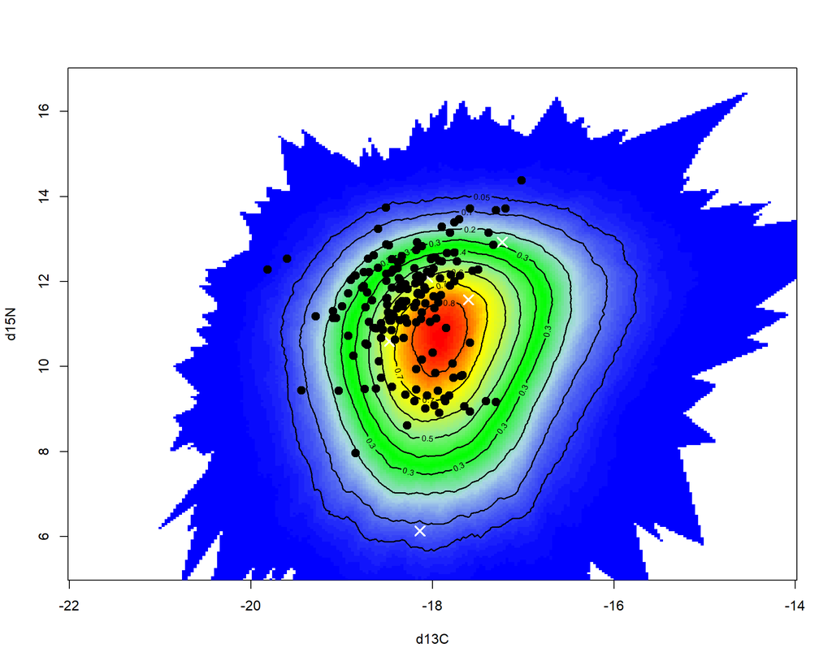

mixing region, consumers, average enriched source signatures

```r
##FIGURE 3: mixing region, consumers, average enriched source signatures
mix_reg <- mix_reg/its  #convert to 0-1 scale
mix_reg[mix_reg==0] <- NA #make the zeros white
mix_regt <- t(mix_reg[ncol(mix_reg):1,])  #transpose matrix for use with 'image'


image(C_g, N_g, mix_regt, col=colorRampPalette(c("blue", "light blue", "green", "light green",
             "yellow", "red"))(100), xlab="d13C", ylab="d15N", useRaster=T)
cont <- c(0.05, seq(0.1, 1, by=0.1))
contour(C_g, N_g, mix_regt, levels=cont, add=TRUE, drawlabels=T, lwd=1.9)
sources_TEF <- sources + TEF
points(sources_TEF[,1], sources_TEF[,3], col="white", pch=4, lwd=2, cex=1.5)
points(mixture, pch=19, cex=1.3)
```

```r
#dev.copy2pdf(file="SIA/OUTPUT/Mix_RegionMED.pdf")
```

delete points outside 95% interval

```r
mixture$insidepolygon95 <- P

med_filtered <- merge(WMed, mixture, by = c("dC_corr", "dN")) %>%
  dplyr:: filter(insidepolygon95 == 1)  %>%
  dplyr:: select(dC_corr, dN)

#write.table(med_filtered, "SIA/MixSIAR/INPUT/swomed_filtered.csv", append = F, sep = ",", dec = ".", row.names = F, col.names = TRUE)
```

> MixSIAR

```r
## Load mix data
mix.filename <- "SIA/MixSIAR/INPUT/swomed_filtered.csv"
mix <- load_mix_data(filename=mix.filename,
   iso_names=c("dC_corr","dN"),
   factors= NULL,
   fac_random=NULL,
   fac_nested=NULL,
   cont_effects=NULL)

## Load source data
source.filename <- "SIA/MixSIAR/INPUT/prey_sourcesMED.csv"
source <- load_source_data(filename=source.filename,
         source_factors=NULL,
         conc_dep=FALSE,
         data_type="means",
         mix)

## Load discrimination data
discr.filename <- "SIA/MixSIAR/INPUT/df_SWO.csv"
discr <- load_discr_data(filename=discr.filename,
       mix)
```

Define model structure and write JAGS model file

```r
model_filename <- "SIA/MixSIAR/MixSIAR_model_SWO_MED.txt"   # Name of the JAGS model file
resid_err <- TRUE
process_err <- TRUE
write_JAGS_model(model_filename, resid_err, process_err, mix, source)

## Run the JAGS model
a=Sys.time()
jags.uninf <- run_model(run="extreme",mix,source,discr,model_filename,alpha.prior = 1, resid_err, process_err)
Sys.time()-a

## Process diagnostics, summary stats, and posterior plots
output_JAGS(jags.uninf, mix, source,
      output_options = list(summary_save = TRUE, summary_name = "SIA/MixSIAR/summary_statistics_swomed",
          sup_post = FALSE, plot_post_save_pdf = F, plot_post_name = "", sup_pairs = F, plot_pairs_save_pdf =F, plot_pairs_name = "", sup_xy= F, plot_xy_save_pdf = F, plot_xy_name = "",
          gelman = TRUE, heidel = FALSE, geweke = TRUE,
          diag_save = T, diag_name = "SIA/MixSIAR/diagnostics_med_SWO",
          indiv_effect = FALSE, plot_post_save_png = FALSE, plot_pairs_save_png = F, plot_xy_save_png = FALSE, diag_save_ggmcmc = TRUE))

save(jags.uninf, file = "SIA/MixSIAR/swo_MED.RData")
```

### 3.3.2 PGO

> MixingPolygons

```r
##USER INPUT
sources <- read.table("SIA/MixSIAR/INPUT/prey_sourcesMED_sharks.csv",header=T,sep=",") %>%
  dplyr::select(-Source, -n)  #always put 13C(x) before 15N(y)

WMed <- samples %>%
  filter(Area1 == "WMed" & Species == "PGO") %>%
  dplyr::select(dC_corr, dN, FL)

mixture = as.data.frame(WMed)

TEF <-  read.table("SIA/MixSIAR/INPUT/df_PGO.csv", header=T,sep=",") %>%
  dplyr::select(-Source)

##Now RUN the simulation
Par_values <- array(0, c(its,(nrow(sources)*4+3)))  #create files to store data
p <- array(0, c(its,(nrow(mixture))))
mix_reg <- array(0, c(res,res))
for (i in 1:its) {    #run loops to generate source isotopic signatures, for iterations = 'its'
  v <- array(0, c(nrow(sources),2))
  f <- array(0, c(nrow(TEF),2))
  for (j in 1:nrow(sources)) {
    v[j,1] <- rnorm(1, mean=sources[j,1], sd=sources[j,2])  #generate values from norm. dist. for d13C
    v[j,2] <- rnorm(1, mean=sources[j,3], sd=sources[j,4])  #generate values from norm. dist. for d15N
    f[j,1] <- rnorm(1, mean=TEF[j,1], sd=TEF[j,2])  #generate values from norm. dist. for d13C enrichment
    f[j,2] <- rnorm(1, mean=TEF[j,3], sd=TEF[j,4])  #generate values from norm. dist. for d15N enrichment
  }
  V <- v+f
  hull <- chull(V)  #create a 2D convex hull from the enriched sources
  hull_a <- append(hull,hull[1])  #closes the polygon
  P <- point.in.polygon(mixture[,1], mixture[,2], V[hull_a,1], V[hull_a,2]) #calculate P_I_P
  P_n <- as.numeric(P)
  p[i,] <- P_n
  poly_a <- areapl(V[hull_a,])  #calculate polygon area, for evaluating the quantity of iterations
  m$y_f <- m$y[res:1,]  #flip y grid data to resemble axes (d13C=x, d15N=y)
  m_r <- point.in.polygon(m$x, m$y_f, V[hull_a,1], V[hull_a,2]) #calculate P-I-P for the mixing region
  m_r_s <- matrix(m_r,nrow=res,byrow=F)  #convert vector into square matrix
  m_r_s[m_r_s > 1] <- 1  #point.in.polygon can return '2' or '3'
  mix_reg <- mix_reg + m_r_s
  vals <- c(v[,1],v[,2],f[,1],f[,2],0,0,0)  #concatenate values for this iteration
  Par_values[i,] <- vals  #store values
  Par_values[i,ncol(Par_values)-2] <- poly_a
  Par_values[i,ncol(Par_values)-1] <- i
  Par_values[i,ncol(Par_values)] <- var(Par_values[1:i,ncol(Par_values)-2])
  if (i %% 10 ==0) cat(paste("iteration", i, "\n"))
}

##FIGURE 2: proportion of iterations that each consumer was inside mixing polygon
p[p > 1] <- 1   #point.in.polygon can return '2' or '3'
Probabilities <- colSums(p)/its
#print(Probabilities>0.05)
P <- ifelse(Probabilities>0.05, 1, 0)
sum(P/nrow(mixture)*100)
sum(P)
```

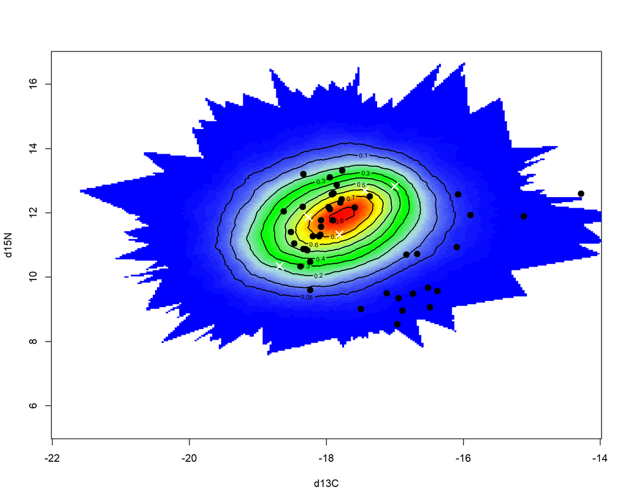

mixing region, consumers, average enriched source signatures

```r
##FIGURE 3: mixing region, consumers, average enriched source signatures
mix_reg <- mix_reg/its  #convert to 0-1 scale
mix_reg[mix_reg==0] <- NA #make the zeros white
mix_regt <- t(mix_reg[ncol(mix_reg):1,])  #transpose matrix for use with 'image'


image(C_g, N_g, mix_regt, col=colorRampPalette(c("blue", "light blue", "green", "light green",
             "yellow", "red"))(100), xlab="d13C", ylab="d15N", useRaster=T)
cont <- c(0.05, seq(0.1, 1, by=0.1))
contour(C_g, N_g, mix_regt, levels=cont, add=TRUE, drawlabels=T, lwd=1.9)
sources_TEF <- sources + TEF
points(sources_TEF[,1], sources_TEF[,3], col="white", pch=4, lwd=2, cex=1.5)
points(mixture, pch=19, cex=1.3)
```

```r
#dev.copy2pdf(file="SIA/OUTPUT/Mix_RegionMED.pdf")
```

delete points outside 95% interval

```r
mixture$insidepolygon95 <- P

med_filtered <- merge(WMed, mixture, by = c("dC_corr", "dN", "FL")) %>%
  dplyr:: filter(insidepolygon95 == 1)  %>%
  dplyr:: select(dC_corr, dN, FL)

write.table(med_filtered, "SIA/MixSIAR/INPUT/pgomed_filtered.csv", append = F, sep = ",", dec = ".", row.names = F, col.names = TRUE)
```

> MixSIAR

```r
## Load mix data
mix.filename <- "SIA/MixSIAR/INPUT/pgomed_filtered.csv"
mix <- load_mix_data(filename=mix.filename,
   iso_names=c("dC_corr","dN"),
   factors= NULL,
   fac_random=NULL,
   fac_nested=NULL,
   cont_effects=NULL)

## Load source data
source.filename <- "SIA/MixSIAR/INPUT/prey_sourcesMED_sharks.csv"
source <- load_source_data(filename=source.filename,
         source_factors=NULL,
         conc_dep=FALSE,
         data_type="means",
         mix)

## Load discrimination data
discr.filename <- "SIA/MixSIAR/INPUT/df_PGO.csv"
discr <- load_discr_data(filename=discr.filename,
       mix)
```

Define model structure and write JAGS model file

```r
model_filename <- "SIA/MixSIAR/MixSIAR_model_PGO_MED.txt"   # Name of the JAGS model file
resid_err <- TRUE
process_err <- TRUE
write_JAGS_model(model_filename, resid_err, process_err, mix, source)

## Run the JAGS model
a=Sys.time()
jags.uninf <- run_model(run="extreme",mix,source,discr,model_filename,alpha.prior = 1, resid_err, process_err)
Sys.time()-a

## Process diagnostics, summary stats, and posterior plots
output_JAGS(jags.uninf, mix, source,
      output_options = list(summary_save = TRUE, summary_name = "SIA/MixSIAR/summary_statistics_PGOmed",
sup_post = FALSE, plot_post_save_pdf = F, plot_post_name = "", sup_pairs = F, plot_pairs_save_pdf =F, plot_pairs_name = "", sup_xy= F, plot_xy_save_pdf = F, plot_xy_name = "",
          gelman = TRUE, heidel = FALSE, geweke = TRUE,
          diag_save = T, diag_name = "SIA/MixSIAR/diagnostics_PGOmed",
          indiv_effect = FALSE, plot_post_save_png = FALSE, plot_pairs_save_png = F, plot_xy_save_png = FALSE, diag_save_ggmcmc = TRUE))

save(jags.uninf, file = "SIA/MixSIAR/PGO_MED.RData")
```

## 3.4 Plot diet proportions

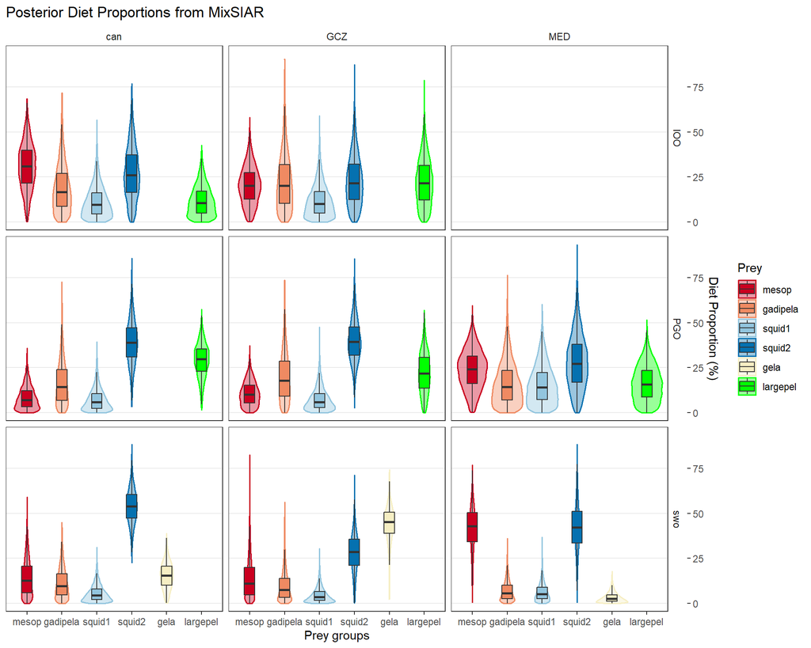

*Figure 5* . Relative consumption of prey in the diet of swordfish, blue sharks, and mako sharks from (a) the Canary Islands, (b) the South of Portugal/Gulf of Cádiz , and (c) the western Mediterranean Sea obtained through Bayesian Stable Isotope Mixing Models (BSIMM).

```r
#results <- read_excel("SIA/MixSIAR/results_MixSIAR.xlsx")
models  <- dir(pattern=".RData")

results <-  data.frame(mesop = NA, gadipela= NA, squid1 = NA, squid2= NA, gela= NA, largepel = NA, species= NA, area= NA)

for (i in 1:length(models)) {
  file <- models[i]
  species <- strsplit(file, "_")[[1]]
  area <- sub("\\.RData", "", species[2])  # "can", removing the ".RData" suffix

  file_path <- paste("", file, sep = "") # Adjust the path accordingly
  load(file_path)
  posterior_diet_proportions <- jags.uninf$BUGSoutput$sims.list$p.global
  posterior_df <- data.frame(posterior_diet_proportions)
  if (species[1] == "swo") {
  colnames(posterior_df) <- c("bathy","ceph1","ceph2","gadipela","gela")
  posterior_df = posterior_df  %>%
    mutate(species = species[1], area = area)

  results  <-  results  %>% add_row(mesop = posterior_df$bathy, gadipela= posterior_df$gadipela,
                                    squid1 = posterior_df$ceph1, squid2= posterior_df$ceph2,
                                    gela= posterior_df$gela, largepel = NA, species= posterior_df$species,
                                    area= posterior_df$area)
  } else {
  colnames(posterior_df) <- c("bathy","ceph1","ceph2","gadipela","largepel")
  posterior_df = posterior_df  %>%
    mutate(species = species[1], area = area)

  results  <-  results  %>% add_row(mesop = posterior_df$bathy, gadipela= posterior_df$gadipela,
                                    squid1 = posterior_df$ceph1, squid2= posterior_df$ceph2,
                                    gela= NA, largepel = posterior_df$largepel, species= posterior_df$species,
                                    area= posterior_df$area)


  }
 }

# Reshape the data for ggplot2
library(reshape2)
posterior_melt <- melt(results, variable.name = "Prey", value.name = "Proportion") %>%
  drop_na() %>%
  mutate(Proportion = Proportion*100)

pal <- c("#CA0020","#EF8A62", "#92C5DE", "#0571B0","#F6EEC3","green")

ggplot(posterior_melt, aes(x = Prey, y = Proportion, fill = Prey)) +
  geom_violin(alpha = 0.4, aes(color = Prey), lwd = 0.6) +
  geom_boxplot(width = 0.3, outlier.shape = NA) +
  facet_grid(species~area) +
  labs(x = "Prey groups", y = "Diet Proportion (%)", title = "Posterior Diet Proportions from MixSIAR") +
  theme_bw() +
  scale_fill_manual(values=pal) +  # Fill colors using viridis palette
  scale_color_manual(values=pal) +
  scale_y_continuous(position = "right") +    # Move y-axis labels to the right
  theme(panel.grid.major.x = element_blank(), panel.grid.minor.y = element_blank(),
         strip.background = element_blank())
```